# LL5532X Course Project on The Proceedings of the Old Bailey

# NLP Problem3: Multi-class classification

## Research Q 3. Predicting Punishment Type from Case Features using the Old Bailey Dataset

## 1. Abstract

This notebook implements a comprehensive study on predicting punishment types (hard labour, non‑custodial/institutional, custodial/prison, capital/extreme) from the Old Bailey dataset. We compare classical ML models (Naive Bayes, Logistic Regression, Random Forest) with a transformer‑based model (Legal‑BERT). Extensive feature engineering, class imbalance handling, and SHAP explanations are provided. The goal is both technical prediction and legal analysis of sentencing patterns.

## 2. Introduction

The Old Bailey Proceedings Online offers a rich historical corpus of London criminal trials (1674–1913). This project uses guilty verdicts to predict punishment subcategories. Understanding what factors influence punishment can shed light on judicial consistency and potential biases.

**Primary research question:** Can we predict punishment type from case features (structured + text)?  
**Secondary:** Compare models; analyse feature importance; explore legal/ethical implications.

## 3. Setup and Data Loading

First, install required libraries (run once).

```python
 # !pip install pandas numpy scikit-learn imbalanced-learn transformers torch shap matplotlib seaborn xgboost
```

```python
!python --version
```

```
Python 3.11.15
```

```python
# !pip install gensim smart_open==6.0.0
# !pip install pycaret
# !pip install "pycaret[tuners]"
# !pip install "pycaret[analysis]"
# !pip install interpret-community
# !pip install nltk
```

```python
import pandas as pd
import numpy as np
import re
import matplotlib.pyplot as plt
import seaborn as sns
from sklearn.model_selection import train_test_split, StratifiedKFold, cross_val_score
from sklearn.feature_extraction.text import TfidfVectorizer
from sklearn.naive_bayes import MultinomialNB
from sklearn.linear_model import LogisticRegression
from sklearn.ensemble import RandomForestClassifier
from sklearn.metrics import classification_report, confusion_matrix, accuracy_score, f1_score
from sklearn.preprocessing import LabelEncoder, StandardScaler
from imblearn.over_sampling import SMOTE
from imblearn.pipeline import Pipeline as ImbPipeline
import warnings
warnings.filterwarnings('ignore')

# For BERT
import torch
from transformers import AutoTokenizer, AutoModelForSequenceClassification, Trainer, TrainingArguments
from torch.utils.data import Dataset

# For SHAP
import shap

print('Libraries imported.')
```

```
Libraries imported.
```

```python
import matplotlib
print(matplotlib.__version__)
```

```
3.7.5
```

### Load the dataset

Adjust file path accordingly.

```python
# Load data/kaggle/input/datasets/kalyanidataanlytics/old-bailey-guilty/RQ3.csv\
df = pd.read_csv(r'C:\Users\swami\OneDrive\Attachments\Law\project\RQ3.csv')
print('Shape:', df.shape)
df.head()
```

```
Shape: (6945, 60)
```

|  | Unnamed: 0 | date | id | text | any_defendant_female | any_defendant_male | any_victim_female | any_victim_male | offenceText | offenceCategory | ... | topic_3_prob | topic_4_prob | topic_5_prob | topic_6_prob | topic_7_prob | topic_8_prob | topic_9_prob | dominant_topic | punishmentCategory_class | punishmentSubcategory_group |
| --- | --- | --- | --- | --- | --- | --- | --- | --- | --- | --- | --- | --- | --- | --- | --- | --- | --- | --- | --- | --- | --- |
| 0 | 0 | 19020113 | t19020113-105 | 105. WALTER HEATH (82) , PLEADED GUILTY to ste... | False | True | False | True | stealing £13, the money ofGeorge Whitehead, hi... | theft | ... | 0.907886 | 0.004546 | 0.004546 | 0.004546 | 0.055744 | 0.004546 | 0.004546 | 3 | severe | hardLabour |
| 1 | 1 | 19020113 | t19020113-2 | (106) THOMAS GEORGE WAKEFIELD , to forging and... | False | True | False | False | , to forging and uttering an undertaking for t... | deception | ... | 0.952628 | 0.005264 | 0.005264 | 0.005264 | 0.005264 | 0.005263 | 0.005264 | 3 | severe | custodial/prison |
| 2 | 2 | 19020113 | t19020113-3 | (107) FREDERICK JOHN RIDGWELL (29) , to steali... | False | True | False | False | , to stealing, while employed under the Post O... | theft | ... | 0.762336 | 0.202878 | 0.004348 | 0.004348 | 0.004348 | 0.004348 | 0.004348 | 3 | severe | hardLabour |
| 3 | 3 | 19020113 | t19020113-4 | (108) WALTER LACEY (38) , to forging an author... | False | True | False | False | , to forging an authority for the withdrawal o... | deception | ... | 0.701157 | 0.248838 | 0.006251 | 0.006251 | 0.006251 | 0.006250 | 0.006250 | 3 | severe | custodial/prison |
| 4 | 4 | 19020113 | t19020113-5 | (109) JOSEPH EDWARD MOULTON (34) , to stealing... | False | True | False | False | , to stealing, while employed under the Post O... | theft | ... | 0.771626 | 0.195038 | 0.004167 | 0.004167 | 0.004167 | 0.004167 | 0.004167 | 3 | severe | hardLabour |

5 rows × 60 columns

```python
df.shape
```

```
(6945, 60)
```

```python
df.info()
```

```
<class 'pandas.core.frame.DataFrame'>
RangeIndex: 6945 entries, 0 to 6944
Data columns (total 60 columns):
 #   Column                        Non-Null Count  Dtype
---  ------                        --------------  -----
 0   Unnamed: 0                    6945 non-null   int64
 1   date                          6945 non-null   int64
 2   id                            6945 non-null   object
 3   text                          6945 non-null   object
 4   any_defendant_female          6945 non-null   bool
 5   any_defendant_male            6945 non-null   bool
 6   any_victim_female             6945 non-null   bool
 7   any_victim_male               6945 non-null   bool
 8   offenceText                   6945 non-null   object
 9   offenceCategory               6945 non-null   object
```

[output cut: 52 more lines]

### Target distribution

Check class imbalance.

```
punishmentSubcategory_group
hardLabour                     3598
custodial/prison               1992
non-custodial/institutional    1280
capital/extreme                  75
Name: count, dtype: int64
```

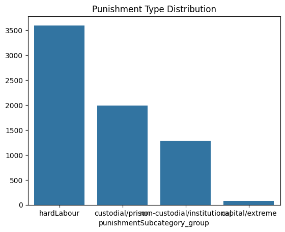

```python
target_counts = df['punishmentSubcategory_group'].value_counts()
print(target_counts)
sns.barplot(x=target_counts.index, y=target_counts.values)
plt.title('Punishment Type Distribution')
plt.show()
```

## 4. Preprocessing and Feature Engineering

We will:

- Handle missing values
- Encode categorical variables
- Create additional features (interactions, temporal, severity proxy, etc.)
- Prepare text for TF-IDF and BERT

```python
# 1. Missing values
# Drop rows with missing target or essential columns
essential_cols = ['punishmentSubcategory_group', 'offenceCategory', 'text']
df.dropna(subset=essential_cols, inplace=True)
```

```python
# For continuous features, median imputation (example for sentiment scores)
sentiment_cols = ['sentiment_positive', 'sentiment_negative', 'sentiment_neutral']
for col in sentiment_cols:
    if col in df.columns:
        df[col].fillna(df[col].median(), inplace=True)
```

```python
df.isnull().sum()
```

```
Unnamed: 0                      0
date                            0
id                              0
text                            0
any_defendant_female            0
any_defendant_male              0
any_victim_female               0
any_victim_male                 0
offenceText                     0
offenceCategory                 0
offenceSubcategory              0
verdictText                     0
verdictCategory                 0
punishmentText                  0
punishmentCategory              0
punishmentSubcategory           0
defendantNames                  0
victimNames                     0
guilty                          0
year                            0
text_length                     0
log_text_length                 0
clean_text_with_stopwords       0
tokens_with_stopwrds            0
clean_text_with_no_stopword     0
tokens_lemma_with_no_stopwor    0
noun_count                      0
verb_count                      0
adj_count                       0
adv_count                       0
pron_count                      0
num_count                       0
person_count                    0
location_count                  0
date_count                      0
money_count                     0
org_count                       0
total_entities                  0
sentiment_compound              0
sentiment_pos                   0
sentiment_neg                   0
sentiment_neu                   0
flesch_reading_ease             0
flesch_kincaid_grade            0
gunning_fog                     0
smog_index                      0
automated_readability_index     0
topic_0_prob                    0
topic_1_prob                    0
topic_2_prob                    0
topic_3_prob                    0
topic_4_prob                    0
topic_5_prob                    0
topic_6_prob                    0
topic_7_prob                    0
topic_8_prob                    0
topic_9_prob                    0
dominant_topic                  0
punishmentCategory_class        0
punishmentSubcategory_group     0
dtype: int64
```

here the data is cleaned. we can strt building feature engineering

```python
# 2. Encode categoricals
categorical_cols = ['offenceCategory', 'offenceSubcategory', 'verdictCategory']
df[categorical_cols]
```

|  | offenceCategory | offenceSubcategory | verdictCategory |
| --- | --- | --- | --- |
| 0 | theft | stealingFromMaster | guilty |
| 1 | deception | forgery | guilty |
| 2 | theft | mail | guilty |
| 3 | deception | forgery | guilty |
| 4 | theft | mail | guilty |
| ... | ... | ... | ... |
| 6940 | theft | simpleLarceny | guilty |
| 6941 | breakingPeace | wounding | guilty |
| 6942 | sexual | rape | guilty |
| 6943 | sexual | sodomy | guilty |
| 6944 | damage | damageNoDetail | guilty |

6945 rows × 3 columns

# Text Representation

After getting the data, we are not yet ready to feed the data into a machine learning model to perform classification tasks. There are a lot of special characters, punctuations, and stopwords in our text. Second, we also need to come up with a way to represent our text.

### Get the text body and the label

```python
df.columns
```

```
Index(['Unnamed: 0', 'date', 'id', 'text', 'any_defendant_female',
       'any_defendant_male', 'any_victim_female', 'any_victim_male',
       'offenceText', 'offenceCategory', 'offenceSubcategory', 'verdictText',
       'verdictCategory', 'punishmentText', 'punishmentCategory',
       'punishmentSubcategory', 'defendantNames', 'victimNames', 'guilty',
       'year', 'text_length', 'log_text_length', 'clean_text_with_stopwords',
       'tokens_with_stopwrds', 'clean_text_with_no_stopword',
       'tokens_lemma_with_no_stopwor', 'noun_count', 'verb_count', 'adj_count',
       'adv_count', 'pron_count', 'num_count', 'person_count',
       'location_count', 'date_count', 'money_count', 'org_count',
       'total_entities', 'sentiment_compound', 'sentiment_pos',
       'sentiment_neg', 'sentiment_neu', 'flesch_reading_ease',
       'flesch_kincaid_grade', 'gunning_fog', 'smog_index',
       'automated_readability_index', 'topic_0_prob', 'topic_1_prob',
       'topic_2_prob', 'topic_3_prob', 'topic_4_prob', 'topic_5_prob',
       'topic_6_prob', 'topic_7_prob', 'topic_8_prob', 'topic_9_prob',
       'dominant_topic', 'punishmentCategory_class',
       'punishmentSubcategory_group'],
      dtype='object')
```

```python
df.offenceText
```

```
0       stealing £13, the money ofGeorge Whitehead, hi...
1       , to forging and uttering an undertaking for t...
2       , to stealing, while employed under the Post O...
3       , to forging an authority for the withdrawal o...
4       , to stealing, while employed under the Post O...
                              ...
6940    ,pleaded guiltyof stealing one coat and one fr...
6941    ,pleaded guiltyof feloniously woundingAda Flor...
6942    , attempting to carnally know a girl under the...
6943    ; committing an act of gross indecency withWil...
6944    , feloniously procuring and inciting a person ...
Name: offenceText, Length: 6945, dtype: object
```

Data Cleaning has been performed in EDA process so we already have clean text column present in the data from the previous work, so taking it further

```python
df_text = df[['clean_text_with_no_stopword']]
df_text.tail()
```

|  | clean_text_with_no_stopword |
| --- | --- |
| 6940 | baker john labourer pleaded guilty of stealing... |
| 6941 | sturgess arthur clicker pleaded guilty of felo... |
| 6942 | shepherd john labourer attempting to carnally ... |
| 6943 | andrews ernest labourer committing an act of g... |
| 6944 | pankhurst emmeline feloniously procuring and i... |

```python
df_text.clean_text_with_no_stopword[14]
```

```
"william manning feloniously shooting at annie walklett with intent to murder her mr purcell prosecuted and mr barrett defended henry nicholls t produced and proved a plan of the interior of the mulberry tree twickenham annie walklett i am the wife of george henry walklett a shunter in the service o…
```

```python
type(df_text.clean_text_with_no_stopword[14])
```

```
str
```

so we have string type data, no need to process

# Representing Text: Bag of Words representation

Unsurprisingly, computers can't read text. They can only count. As a result, there are methods for converting text into numbers. This is known as featurization. The simplest of these models are known as "bag-of-words" representations.

## Document Term Matrix - Text Representation with Term Frequency Matrix (TF)

```python
# We can use the CountVectorizer method from sklearn to calculate TF
from sklearn.feature_extraction.text import CountVectorizer

# For the purpose of demonstration, I'll use only few cases from the dataset
text = df_text.sample(20, random_state = 3).reset_index() # reset index to make sure the appending of words as columns works
```

```python
text.head()
```

|  | index | clean_text_with_no_stopword |
| --- | --- | --- |
| 0 | 1420 | harry faulkner irvine embezzling £ s d £ s £ i... |
| 1 | 3463 | courtman john kitchen boy and ingleton albert ... |
| 2 | 3195 | brandon herbert artist and darby frederick art... |
| 3 | 3265 | hackshaw george porter feloniously wounding am... |
| 4 | 6560 | davis george french polisher feloniously attem... |

```python
count_vectorizer = CountVectorizer(stop_words='english')

tf = count_vectorizer.fit_transform(text['clean_text_with_no_stopword'])
count_matrix = pd.DataFrame(data=tf.toarray(),
                            columns = count_vectorizer.get_feature_names_out())
```

To see the "feature names" - meaning - "words" in columns, use `'.get_feature_names_out()'`. This is used to create those columns with words.

```python
count_matrix.head()
```

|  | abertillery | abetting | able | abrasion | abrasions | absenting | absolutely | absurd | ac | accidentally | ... | wrong | wrote | yard | yards | year | years | yellow | yes | yesterday | young |
| --- | --- | --- | --- | --- | --- | --- | --- | --- | --- | --- | --- | --- | --- | --- | --- | --- | --- | --- | --- | --- | --- |
| 0 | 0 | 0 | 0 | 0 | 0 | 1 | 0 | 0 | 1 | 0 | ... | 0 | 2 | 0 | 0 | 0 | 1 | 0 | 1 | 0 | 0 |
| 1 | 0 | 0 | 0 | 0 | 0 | 0 | 0 | 0 | 0 | 0 | ... | 0 | 0 | 0 | 0 | 0 | 0 | 0 | 0 | 0 | 0 |
| 2 | 0 | 0 | 3 | 0 | 0 | 0 | 0 | 0 | 0 | 0 | ... | 0 | 1 | 0 | 0 | 0 | 0 | 0 | 0 | 0 | 0 |
| 3 | 0 | 0 | 0 | 0 | 0 | 0 | 0 | 0 | 0 | 0 | ... | 0 | 0 | 0 | 0 | 1 | 3 | 0 | 1 | 0 | 0 |
| 4 | 0 | 1 | 0 | 0 | 0 | 0 | 1 | 1 | 0 | 0 | ... | 0 | 0 | 0 | 0 | 0 | 8 | 0 | 0 | 1 | 0 |

5 rows × 2154 columns

```python
matrix = pd.concat([text, count_matrix], axis=1)
matrix.head()
```

|  | index | clean_text_with_no_stopword | abertillery | abetting | able | abrasion | abrasions | absenting | absolutely | absurd | ... | wrong | wrote | yard | yards | year | years | yellow | yes | yesterday | young |
| --- | --- | --- | --- | --- | --- | --- | --- | --- | --- | --- | --- | --- | --- | --- | --- | --- | --- | --- | --- | --- | --- |
| 0 | 1420 | harry faulkner irvine embezzling £ s d £ s £ i... | 0 | 0 | 0 | 0 | 0 | 1 | 0 | 0 | ... | 0 | 2 | 0 | 0 | 0 | 1 | 0 | 1 | 0 | 0 |
| 1 | 3463 | courtman john kitchen boy and ingleton albert ... | 0 | 0 | 0 | 0 | 0 | 0 | 0 | 0 | ... | 0 | 0 | 0 | 0 | 0 | 0 | 0 | 0 | 0 | 0 |
| 2 | 3195 | brandon herbert artist and darby frederick art... | 0 | 0 | 3 | 0 | 0 | 0 | 0 | 0 | ... | 0 | 1 | 0 | 0 | 0 | 0 | 0 | 0 | 0 | 0 |
| 3 | 3265 | hackshaw george porter feloniously wounding am... | 0 | 0 | 0 | 0 | 0 | 0 | 0 | 0 | ... | 0 | 0 | 0 | 0 | 1 | 3 | 0 | 1 | 0 | 0 |
| 4 | 6560 | davis george french polisher feloniously attem... | 0 | 1 | 0 | 0 | 0 | 0 | 1 | 1 | ... | 0 | 0 | 0 | 0 | 0 | 8 | 0 | 0 | 1 | 0 |

5 rows × 2156 columns

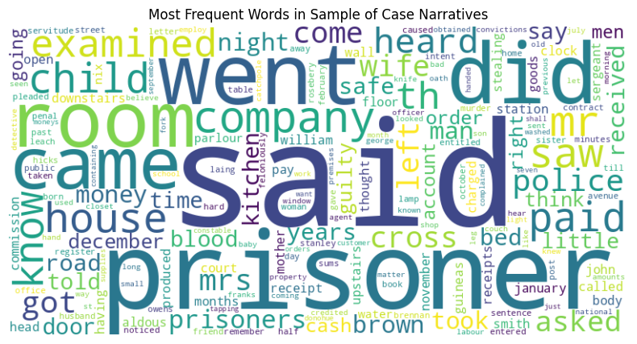

```python
from wordcloud import WordCloud
import matplotlib.pyplot as plt

# Sum frequencies across all documents in the sample
word_freq = count_matrix.sum(axis=0).sort_values(ascending=False)

# Generate word cloud
wordcloud = WordCloud(width=800, height=400, background_color='white').generate_from_frequencies(word_freq)

plt.figure(figsize=(10, 5))
plt.imshow(wordcloud, interpolation='bilinear')
plt.axis('off')
plt.title('Most Frequent Words in Sample of Case Narratives')
plt.show()
```

### Cumulative Frequency Distribution – how many terms account for most of the occurrences?

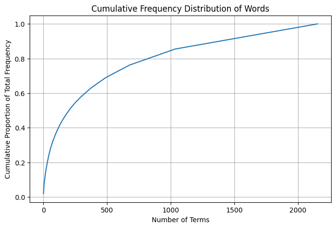

```python
cumulative = word_freq.cumsum() / word_freq.sum()
plt.figure(figsize=(8, 5))
plt.plot(range(1, len(cumulative)+1), cumulative)
plt.xlabel('Number of Terms')
plt.ylabel('Cumulative Proportion of Total Frequency')
plt.title('Cumulative Frequency Distribution of Words')
plt.grid(True)
plt.show()
```

The cumulative proportion of total word occurrences as we include more and more distinct terms, sorted from most frequent to least frequent.

Justifies dimensionality reduction (e.g., limiting TF‑IDF to the top N features). Shows that you can capture most of the textual signal with a relatively small vocabulary, which helps prevent overfitting and speeds up training. Confirms that removing rare words (using min_df) has little impact on overall content.

## raw count-based text representation and Zipf's law

```python
import numpy as np
import random
from sklearn.feature_extraction.text import CountVectorizer

data = text['clean_text_with_no_stopword']

# Get Baseline
baseline_cv = CountVectorizer().fit(data)
baseline_words = set(baseline_cv.get_feature_names_out())
baseline_count = len(baseline_words)

print(f"BASELINE: No filtering | Total Unique Words: {baseline_count}")
print("=" * 60)

# Loop through thresholds
for number in np.arange(0.5, 1.0, step=0.05):
    max_val = round(number, 2)
    min_val = round(1 - number, 2)

    #  MAX_DF Logic
    cv_max = CountVectorizer(max_df=max_val).fit(data)
    max_words = set(cv_max.get_feature_names_out())
    removed_max = sorted(list(baseline_words - max_words))

    #  MIN_DF Logic
    cv_min = CountVectorizer(min_df=min_val).fit(data)
    min_words = set(cv_min.get_feature_names_out())
    removed_min = list(baseline_words - min_words)

    #  Print Resunts
    print(f"THRESHOLD SET: max_df={max_val} | min_df={min_val}")

    # Show Max_DF details
    print(f"  [max_df] Columns: {len(max_words)} ({len(removed_max)} removed)")
    if removed_max:
        # We show the first 10 alphabetically, which usually captures common stopwords
        print(f"    Example words removed: {removed_max[:10]}")

    # Show Min_DF details
    print(f"  [min_df] Columns: {len(min_words)} ({len(removed_min)} removed)")
    if removed_min:
        # We take a random sample because the list is usually huge
        sample_size = min(len(removed_min), 10)
        print(f"    Example words removed: {random.sample(removed_min, sample_size)}")

    print("-" * 60)
```

```
BASELINE: No filtering | Total Unique Words: 2389
============================================================
THRESHOLD SET: max_df=0.5 | min_df=0.5
  [max_df] Columns: 2370 (19 removed)
    Example words removed: ['and', 'been', 'before', 'for', 'from', 'guilty', 'hard', 'he', 'in', 'months']
  [min_df] Columns: 27 (2362 removed)
    Example words removed: ['causing', 'payments', 'matters', 'opened', 'manner', 'mission', 'recent', 'sixteen', 'harvard', 'lodging']
------------------------------------------------------------
THRESHOLD SET: max_df=0.55 | min_df=0.45
  [max_df] Columns: 2375 (14 removed)
    Example words removed: ['and', 'been', 'from', 'guilty', 'he', 'in', 'months', 'of', 'on', 'pleaded']
  [min_df] Columns: 48 (2341 removed)
    Example words removed: ['purchase', 'ludwig', 'locket', 'fulton', 'leased', 'somers', 'warrant', 'muir', 'communicated', 'train']
------------------------------------------------------------
THRESHOLD SET: max_df=0.6 | min_df=0.4
  [max_df] Columns: 2379 (10 removed)
    Example words removed: ['and', 'guilty', 'in', 'of', 'on', 'pleaded', 'prisoner', 'the', 'to', 'was']
  [min_df] Columns: 66 (2323 removed)
    Example words removed: ['miscarriage', 'dying', 'heat', 'railway', 'cleary', 'man', 'temper', 'eye', 'oars', 'ward']
------------------------------------------------------------
THRESHOLD SET: max_df=0.65 | min_df=0.35
  [max_df] Columns: 2381 (8 removed)
    Example words removed: ['and', 'guilty', 'in', 'of', 'on', 'the', 'to', 'was']
  [min_df] Columns: 87 (2302 removed)
    Example words removed: ['indictment', 'lit', 'paralytic', 'frac', 'extending', 'after', 'refused', 'upstairs', 'quite', 'refuse']
------------------------------------------------------------
THRESHOLD SET: max_df=0.7 | min_df=0.3
  [max_df] Columns: 2383 (6 removed)
    Example words removed: ['and', 'guilty', 'of', 'the', 'to', 'was']
  [min_df] Columns: 137 (2252 removed)
    Example words removed: ['informed', 'keeper', 'smelt', 'struggle', 'portion', 'threatened', 'credit', 'violence', 'looking', 'root']
------------------------------------------------------------
THRESHOLD SET: max_df=0.75 | min_df=0.25
  [max_df] Columns: 2383 (6 removed)
    Example words removed: ['and', 'guilty', 'of', 'the', 'to', 'was']
  [min_df] Columns: 192 (2197 removed)
    Example words removed: ['looks', 'together', 'slightest', 'bassett', 'muffle', 'count', 'postings', 'employers', 'near', 'hutch']
------------------------------------------------------------
THRESHOLD SET: max_df=0.8 | min_df=0.2
  [max_df] Columns: 2384 (5 removed)
    Example words removed: ['and', 'guilty', 'of', 'the', 'to']
  [min_df] Columns: 281 (2108 removed)
    Example words removed: ['clara', 'appeared', 'decorator', 'practising', 'march', 'further', 'eventually', 'painting', 'tember', 'child']
------------------------------------------------------------
THRESHOLD SET: max_df=0.85 | min_df=0.15
  [max_df] Columns: 2384 (5 removed)
    Example words removed: ['and', 'guilty', 'of', 'the', 'to']
  [min_df] Columns: 458 (1931 removed)
    Example words removed: ['officers', 'felt', 'scratch', 'drinks', 'usual', 'connection', 'instructed', 'killed', 'dated', 'probably']
------------------------------------------------------------
THRESHOLD SET: max_df=0.9 | min_df=0.1
  [max_df] Columns: 2384 (5 removed)
    Example words removed: ['and', 'guilty', 'of', 'the', 'to']
  [min_df] Columns: 833 (1556 removed)
    Example words removed: ['posed', 'thief', 'payments', 'cleared', 'victions', 'chased', 'wiping', 'section', 'rarely', 'lungs']
------------------------------------------------------------
THRESHOLD SET: max_df=0.95 | min_df=0.05
  [max_df] Columns: 2386 (3 removed)
    Example words removed: ['guilty', 'of', 'the']
  [min_df] Columns: 2389 (0 removed)
------------------------------------------------------------
```

```python
total_docs = len(data)

# Get Baseline
baseline_cv = CountVectorizer().fit(data)
baseline_words = set(baseline_cv.get_feature_names_out())
baseline_count = len(baseline_words)

print(f"BASELINE: No filtering | Total Docs: {total_docs} | Unique Words: {baseline_count}")
print("=" * 60)

min_df_tests = [1, 2, 3, 5, 10, 15]
max_df_tests = [int(total_docs * 0.5), int(total_docs * 0.7), int(total_docs * 0.9)]

for i in range(len(min_df_tests)):
    m_idx = min(i, len(max_df_tests) - 1)
    curr_min = min_df_tests[i]
    curr_max = max_df_tests[m_idx]

    try:
        # --- MAX_DF Logic (Showing what is removed) ---
        cv_max = CountVectorizer(max_df=curr_max).fit(data)
        max_words = set(cv_max.get_feature_names_out())
        removed_max = sorted(list(baseline_words - max_words))

        # --- MIN_DF Logic (Showing what REMAINS) ---
        cv_min = CountVectorizer(min_df=curr_min).fit(data)
        # We transform to get actual counts so we can show the most frequent remaining words
        counts = cv_min.fit_transform(data).sum(axis=0).A1
        words_min = cv_min.get_feature_names_out()

        # Combine into a temporary list for sorting by frequency
        word_freq = sorted(zip(words_min, counts), key=lambda x: x[1], reverse=True)
        remaining_words = [w for w, f in word_freq]

        # --- PRINT RESULTS ---
        print(f"THRESHOLD SET: max_df={curr_max} | min_df={curr_min}")
        print(f"  [max_df] Keeps: {len(max_words)} ({len(removed_max)} removed)")

        print(f"  [min_df] Keeps: {len(remaining_words)} ({baseline_count - len(remaining_words)} removed)")
        if remaining_words:
            # Show top 10 most frequent surviving words
            print(f"    Top 10 Remaining Words: {remaining_words[:10]}")
            # Show a random 5 surviving words to see the variety
            sample_size = min(len(remaining_words), 5)
            print(f"    Random Sample Remaining: {random.sample(remaining_words, sample_size)}")

    except ValueError:
        print(f"THRESHOLD SET: max_df={curr_max} | min_df={curr_min}")
        print(f"  [!] Skipping: No words survived this min_df.")

    print("-" * 60)
```

```
BASELINE: No filtering | Total Docs: 20 | Unique Words: 2389
============================================================
THRESHOLD SET: max_df=10 | min_df=1
  [max_df] Keeps: 2370 (19 removed)
  [min_df] Keeps: 2389 (0 removed)
    Top 10 Remaining Words: ['the', 'and', 'to', 'of', 'was', 'in', 'he', 'on', 'not', 'had']
    Random Sample Remaining: ['sup', 'timber', 'possible', 'outside', 'regards']
------------------------------------------------------------
THRESHOLD SET: max_df=14 | min_df=2
  [max_df] Keeps: 2383 (6 removed)
  [min_df] Keeps: 833 (1556 removed)
    Top 10 Remaining Words: ['the', 'and', 'to', 'of', 'was', 'in', 'he', 'on', 'not', 'had']
    Random Sample Remaining: ['prisoners', 'arrest', 'felony', 'served', 'city']
------------------------------------------------------------
THRESHOLD SET: max_df=18 | min_df=3
  [max_df] Keeps: 2384 (5 removed)
  [min_df] Keeps: 458 (1931 removed)
    Top 10 Remaining Words: ['the', 'and', 'to', 'of', 'was', 'in', 'he', 'on', 'not', 'had']
    Random Sample Remaining: ['children', 'told', 're', 'fetched', 'it']
------------------------------------------------------------
THRESHOLD SET: max_df=18 | min_df=5
  [max_df] Keeps: 2384 (5 removed)
  [min_df] Keeps: 192 (2197 removed)
    Top 10 Remaining Words: ['the', 'and', 'to', 'of', 'was', 'in', 'he', 'on', 'not', 'had']
    Random Sample Remaining: ['property', 'and', 'on', 'or', 'clock']
------------------------------------------------------------
THRESHOLD SET: max_df=18 | min_df=10
  [max_df] Keeps: 2384 (5 removed)
  [min_df] Keeps: 27 (2362 removed)
    Top 10 Remaining Words: ['the', 'and', 'to', 'of', 'was', 'in', 'he', 'on', 'not', 'that']
    Random Sample Remaining: ['he', 'of', 'to', 'the', 'for']
------------------------------------------------------------
THRESHOLD SET: max_df=18 | min_df=15
  [max_df] Keeps: 2384 (5 removed)
  [min_df] Keeps: 6 (2383 removed)
    Top 10 Remaining Words: ['the', 'and', 'to', 'of', 'was', 'guilty']
    Random Sample Remaining: ['was', 'and', 'guilty', 'of', 'the']
------------------------------------------------------------
```

# N-gram Range hyperparameter

Instead of working with `min_df`, and `max_df`, let's now work with `n_gram range` hyperparameter

```python
for number in np.arange(1 , 5):
    count_vectorizer = CountVectorizer(ngram_range=(1,number))
    tf = count_vectorizer.fit_transform(text['clean_text_with_no_stopword'])
    count_matrix = pd.DataFrame(data=tf.toarray(),columns = count_vectorizer.get_feature_names_out())
    if number == 1:
        print("The number of columns with 1-gram : "  + str(count_matrix.shape[1]))
    elif number == 2:
        print("The number of columns with 1-gram and 2-grams : "  + str(count_matrix.shape[1]))
    elif number == 3:
        print("The number of columns with 1-gram, 2-gram, and 3-grams : "  + str(count_matrix.shape[1]))
    elif number == 4:
        print("The number of columns with 1-gram, 2-gram, 3-gram, and 4-grams : "  + str(count_matrix.shape[1]))
    elif number == 5:
        print("The number of columns with 1-gram , 2-gram, 3-gram, 4-gram, and 5-gram : "  + str(count_matrix.shape[1]))
```

```
The number of columns with 1-gram : 2389
The number of columns with 1-gram and 2-grams : 12971
The number of columns with 1-gram, 2-gram, and 3-grams : 28378
The number of columns with 1-gram, 2-gram, 3-gram, and 4-grams : 45266
```

```python
count_matrix = pd.DataFrame(data=tf.toarray(),
                            columns = count_vectorizer.get_feature_names_out())
count_matrix.head()
```

|  | abertillery | abertillery in | abertillery in wales | abertillery in wales where | abetting | abetting mr | abetting mr franks | abetting mr franks to | able | able story | ... | your sister | your sister saying | your sister saying you | your way | your way because | your way because it | yours | yours should | yours should advise | yours should advise you |
| --- | --- | --- | --- | --- | --- | --- | --- | --- | --- | --- | --- | --- | --- | --- | --- | --- | --- | --- | --- | --- | --- |
| 0 | 0 | 0 | 0 | 0 | 0 | 0 | 0 | 0 | 0 | 0 | ... | 0 | 0 | 0 | 0 | 0 | 0 | 0 | 0 | 0 | 0 |
| 1 | 0 | 0 | 0 | 0 | 0 | 0 | 0 | 0 | 0 | 0 | ... | 0 | 0 | 0 | 0 | 0 | 0 | 0 | 0 | 0 | 0 |
| 2 | 0 | 0 | 0 | 0 | 0 | 0 | 0 | 0 | 3 | 1 | ... | 0 | 0 | 0 | 0 | 0 | 0 | 0 | 0 | 0 | 0 |
| 3 | 0 | 0 | 0 | 0 | 0 | 0 | 0 | 0 | 0 | 0 | ... | 0 | 0 | 0 | 0 | 0 | 0 | 0 | 0 | 0 | 0 |
| 4 | 0 | 0 | 0 | 0 | 1 | 1 | 1 | 1 | 0 | 0 | ... | 0 | 0 | 0 | 0 | 0 | 0 | 0 | 0 | 0 | 0 |

5 rows × 45266 columns

- The number of features increases when we represent words as n-grams larger than 1 (ie bigrams)
- The Matrix is **sparse** as opposed to **dense** - meaning, that there are a lot of zeroes in the matrix. This creates a lot of mathematical challenges.
- This increase of features is called an increase in "dimensionality" - and high-dimensional data presents its own problems, that relate to computation costs, and possibility of finding spurrious correlations or difficulties with finding relationships

```python
# Example: after fitting CountVectorizer with ngram_range=(1,2)
# count_matrix is a DataFrame with documents as rows and n‑grams as columns

# Select rows  (document indices) and columns that are relevant to punishment types
relevant_words = ["hard", "labour", "hard labour", "penal", "servitude", "imprisonment", "without"]
# Keep only those columns that actually exist in count_matrix (some may not be present)
existing_cols = [col for col in relevant_words if col in count_matrix.columns]

subset_df = count_matrix.loc[[10, 14, 4], existing_cols]
subset_df
```

|  | hard | labour | hard labour | penal | servitude | imprisonment | without |
| --- | --- | --- | --- | --- | --- | --- | --- |
| 10 | 1 | 1 | 1 | 4 | 3 | 0 | 0 |
| 14 | 0 | 0 | 0 | 1 | 1 | 0 | 0 |
| 4 | 1 | 1 | 1 | 3 | 3 | 0 | 0 |

### Document Vector

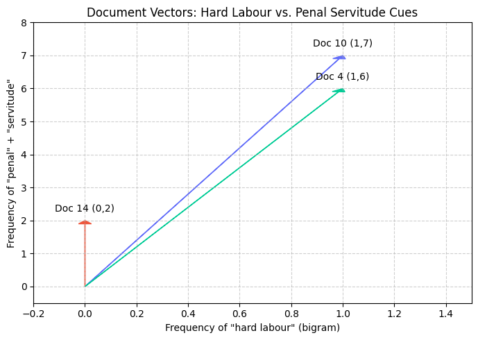

```python
import matplotlib.pyplot as plt

# Actual data from subset_df
data = [
    {"name": "Doc 10", "x": 1, "y": 7},   # hard labour=1, penal+servitude=7
    {"name": "Doc 14", "x": 0, "y": 2},   # hard labour=0, penal+servitude=2
    {"name": "Doc 4", "x": 1, "y": 6}    # hard labour=1, penal+servitude=0
]

colors = ['#636EFA', '#EF553B', '#00CC96']

plt.figure(figsize=(7, 5))
for i, doc in enumerate(data):
    x, y = doc["x"], doc["y"]
    plt.arrow(0, 0, x, y,
              head_width=0.05, head_length=0.1,
              fc=colors[i], ec=colors[i],
              length_includes_head=True)
    plt.text(x, y + 0.2, f"{doc['name']} ({x},{y})",
             fontsize=10, ha='center', va='bottom')

plt.xlim(-0.2, 1.5)
plt.ylim(-0.5, 8)
plt.xlabel('Frequency of "hard labour" (bigram)')
plt.ylabel('Frequency of "penal" + "servitude"')
plt.title('Document Vectors: Hard Labour vs. Penal Servitude Cues')
plt.grid(True, linestyle='--', alpha=0.6)
plt.tight_layout()
plt.show()
```

Doc 10 (1,7) and Doc 4 (1,6) both contain the bigram “hard labour” once, but have very high combined counts of “penal” + “servitude” (7 and 6 respectively). This strongly suggests sentences of penal servitude – a severe, long‑term form of hard labour.

Doc 14 (0,2) has no “hard labour” and only a low penal‑servitude score (2), indicating a milder sentence, likely imprisonment without hard labour.

The separation along the y‑axis (penal‑servitude cues) is striking: documents with high penal‑servitude scores cluster at the top, while the one with low score stays near the origin. This demonstrates that n‑gram features can effectively distinguish between different punishment types, supporting your goal of predicting hard labour vs. imprisonment without hard labour using text and demographic features. In a classification model, “penal” and “servitude” would be strong predictors of the most severe sentences.

## Fightin Words Implementation

The "Fighting Words" approach, introduced by Monroe, Colaresi, and Quinn (2008), solves two key problems in comparing text corpora:

Unequal corpus sizes: The method uses rates (proportions) rather than raw counts, so a word that appears 10 times in a 100-word corpus is treated equivalently to one appearing 100 times in a 1000-word corpus.

Rare word uncertainty: The method adds a smoothing prior (a small number added to all counts) to prevent words that appear only once or twice from being considered highly distinctive by chance. The prior essentially says "we expect most words to be used at roughly the same rate in both corpora unless proven otherwise".

The calculation proceeds in three steps:

Step 1: Smoothing – Add a small prior (default 0.01) to each word's count in both classes.

Step 2: Log-Odds Ratio – Calculate the log of the ratio of smoothed proportions, which gives a signed measure of association (positive = more common in class 1, negative = more common in class 2).

Step 3: Z-Score – Divide the log-odds by its standard error to get a z-score. Words with |z| > 1.96 are "statistically significant" at the 95% confidence level

```python
import pandas as pd
import numpy as np
from sklearn.feature_extraction.text import CountVectorizer
import matplotlib.pyplot as plt
import seaborn as sns

class FightinWords:
    """
    Implementation of Monroe et al.'s 'Fightin' Words' method for lexical feature selection.
    Identifies words that distinguish two text corpora using log-odds ratios with
    an informative Dirichlet prior.
    """

    def __init__(self, prior=0.01, ngram_range=(1, 2), max_features=5000):
        """
        Parameters:
        - prior: Dirichlet prior (smoothing parameter). Default 0.01 as in the paper.
        - ngram_range: Tuple (min_n, max_n) for n-gram extraction.
        - max_features: Maximum number of features to keep.
        """
        self.prior = prior
        self.ngram_range = ngram_range
        self.max_features = max_features
        self.vectorizer = CountVectorizer(
            ngram_range=ngram_range,
            max_features=max_features,
            stop_words='english',
            min_df=2
        )
        self.vocabulary_ = None
        self.class1_counts_ = None
        self.class2_counts_ = None
        self.total_counts_ = None

    def fit(self, texts1, texts2):
        """
        Fit the model on two lists of texts.

        Parameters:
        - texts1: List of strings for class 1
        - texts2: List of strings for class 2
        """
        # Combine texts to build vocabulary
        all_texts = texts1 + texts2
        self.vocabulary_ = self.vectorizer.fit(all_texts).vocabulary_

        # Transform each class separately
        X1 = self.vectorizer.transform(texts1)
        X2 = self.vectorizer.transform(texts2)

        # Get counts for each class
        self.class1_counts = np.asarray(X1.sum(axis=0)).flatten()
        self.class2_counts = np.asarray(X2.sum(axis=0)).flatten()

        # Total counts for smoothing
        self.total_counts = self.class1_counts + self.class2_counts + 2 * self.prior

        return self

    def compute_z_scores(self):
        """Calculate z-scores for all terms."""
        # Smooth the counts with the Dirichlet prior
        smoothed_class1 = (self.class1_counts + self.prior) / self.total_counts
        smoothed_class2 = (self.class2_counts + self.prior) / self.total_counts

        # Calculate log-odds ratio
        log_odds = np.log(smoothed_class1 / smoothed_class2)

        # Calculate variance and z-scores
        variance = 1 / (self.class1_counts + self.prior) + 1 / (self.class2_counts + self.prior)
        z_scores = log_odds / np.sqrt(variance)

        return z_scores

    def get_fighting_words(self, top_n=20):
        """
        Get the top distinguishing words for each class.

        Parameters:
        - top_n: Number of top words to return for each class

        Returns:
        - DataFrame with columns: word, z_score, class1_count, class2_count, class
        """
        z_scores = self.compute_z_scores()
        feature_names = self.vectorizer.get_feature_names_out()

        # Create results DataFrame
        results = pd.DataFrame({
            'word': feature_names,
            'z_score': z_scores,
            'class1_count': self.class1_counts,
            'class2_count': self.class2_counts
        })

        # Separate words distinctive to each class
        class1_words = results.nlargest(top_n, 'z_score').copy()
        class1_words['class'] = 'Class 1'

        class2_words = results.nsmallest(top_n, 'z_score').copy()
        class2_words['class'] = 'Class 2'

        # Combine and sort
        return pd.concat([class1_words, class2_words], ignore_index=True)

    def plot_fighting_words(self, top_n=15, figsize=(10, 8)):
        """
        Create a horizontal bar chart of the top fighting words.
        """
        results = self.get_fighting_words(top_n)

        fig, axes = plt.subplots(1, 2, figsize=figsize)

        # Class 1 words (positive z-scores)
        class1 = results[results['class'] == 'Class 1'].sort_values('z_score')
        axes[0].barh(class1['word'], class1['z_score'], color='#2E86AB')
        axes[0].set_title('Distinctive to Class 1', fontsize=12)
        axes[0].set_xlabel('Z-Score')
        axes[0].axvline(x=0, color='black', linestyle='-', linewidth=0.5)

        # Class 2 words (negative z-scores)
        class2 = results[results['class'] == 'Class 2'].sort_values('z_score')
        axes[1].barh(class2['word'], class2['z_score'], color='#A23B72')
        axes[1].set_title('Distinctive to Class 2', fontsize=12)
        axes[1].set_xlabel('Z-Score')
        axes[1].axvline(x=0, color='black', linestyle='-', linewidth=0.5)

        plt.suptitle('Fighting Words: Terms That Distinguish the Two Corpora', fontsize=14)
        plt.tight_layout()
        return fig
```

```
is_hard_labour
1    3598
0    3347
Name: count, dtype: int64
               word    z_score  class1_count  class2_count    class
0       hard labour  46.253724          4524           650  Class 1
1            labour  46.077259          4568           720  Class 1
2              hard  45.465630          4780           952  Class 1
3       months hard  45.217350          4291           584  Class 1
4            months  26.183310          6218          3592  Class 1
5   sentence months  23.888338          1574           428  Class 1
6              coin  15.243062          1335           642  Class 1
7      construction  13.763379           506            17  Class 1
8   eighteen months  13.741576           453            98  Class 1
9            postal  13.704471           830           345  Class 1
```

[output cut: 20 more lines]

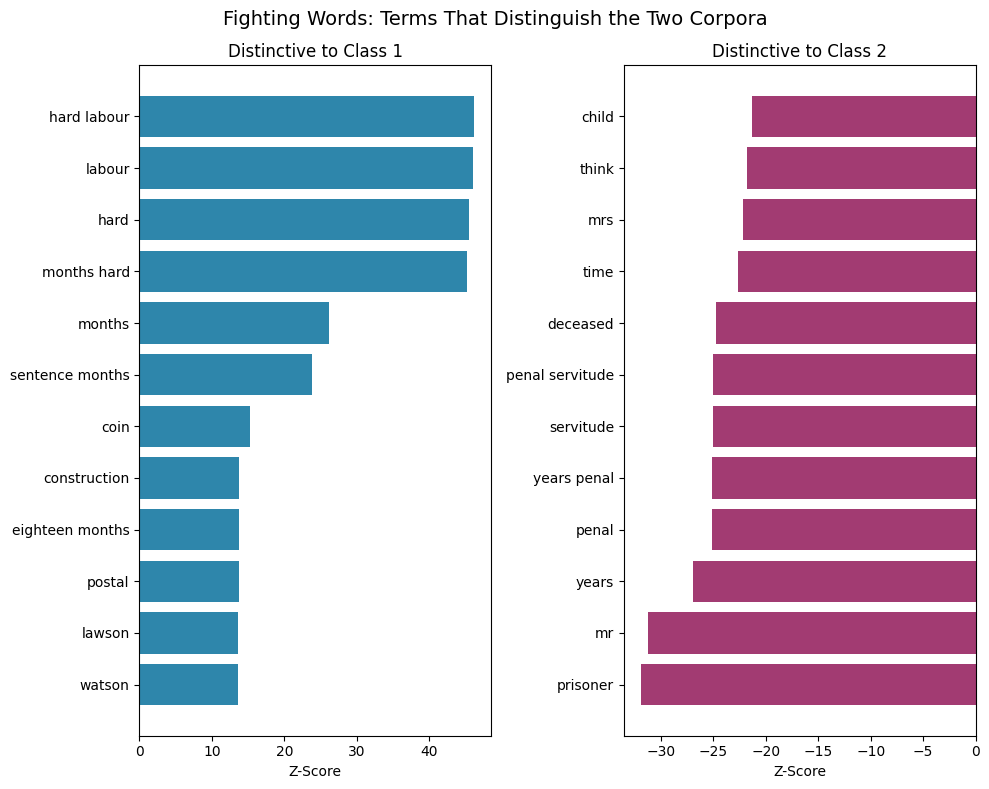

```python
# First, create a guilty-only subset (if not already)
df_guilty = df[df['guilty'] == 1].copy()

# Create binary target: 1 if punishmentSubcategory == 'hardLabour', else 0
# Note: 'no_punishment' rows (non-guilty) are already excluded by the filter above
df_guilty['is_hard_labour'] = (df_guilty['punishmentSubcategory'] == 'hardLabour').astype(int)

# Verify the distribution
print(df_guilty['is_hard_labour'].value_counts())

# Split texts by class
hard_labour_texts = df_guilty[df_guilty['is_hard_labour'] == 1]['clean_text_with_stopwords'].tolist()
other_texts = df_guilty[df_guilty['is_hard_labour'] == 0]['clean_text_with_stopwords'].tolist()

# Now apply the Fighting Words implementation
fw = FightinWords(prior=0.01, ngram_range=(1, 2), max_features=5000)
fw.fit(hard_labour_texts, other_texts)

results = fw.get_fighting_words(top_n=15)
results[['word', 'z_score', 'class1_count', 'class2_count', 'class']].to_string(index=False)
print(results)
fw.plot_fighting_words(top_n=12)
plt.show()
```

Words distinctive to hard labour (Class 1) include the bigram "hard labour" itself, along with its component words "hard" and "labour", as well as temporal phrases like "months hard", "eighteen months", and "sentence months". The presence of "stealing", "coin", "postal", and "florin" (a coin) indicates that theft‑related offences – especially those involving money or postal property – are strongly associated with hard labour sentences. Proper names like "lawson" and "watson" may refer to specific repeat offenders or notable cases.

Words distinctive to other punishments (Class 2) include terms like "prisoner", "mr", "mrs", "deceased", "child", and "dr", suggesting cases involving personal violence, manslaughter, or domestic contexts. The presence of "penal servitude" and related terms ("years penal", "servitude") in Class 2 is at first surprising because penal servitude is a severe form of hard labour. However, in this dataset "hardLabour" is a specific subcategory, while "penalServitude" is treated separately – thus "penal servitude" appears as a cue for a different type of sentence (long‑term hard labour), which the model groups with other non‑standard punishments. The word "imprisonment" also appears in Class 2, as expected for non‑hard‑labour custodial sentences.

Key takeaway: The most powerful positive predictor of a hard labour sentence is the explicit mention of "hard labour" itself, followed by words related to theft and short‑term duration. Cases that mention "penal servitude", "imprisonment", or personal references (victims, children, doctors) tend to fall into the “other punishments” category. This lexical divergence validates the use of text features for predicting punishment type and highlights specific phrases that could be used to flag potential inconsistencies in sentencing.

```
               word    z_score  class1_count  class2_count   class
       imprisonment  18.356821           727           116 Class 1
    second division  15.470712           518            36 Class 1
months imprisonment  15.211075           494            75 Class 1
imprisonment second  11.866868           355            14 Class 1
             leslie  10.179053           255            58 Class 1
  days imprisonment   9.222841           187            12 Class 1
         electrical   9.131593           188            35 Class 1
             webber   8.692963           253             5 Class 1
           economic   8.038722           137            20 Class 1
      months second   8.012515           133            15 Class 1
              items   7.372494           144            37 Class 1
        accessories   7.105597           105            10 Class 1
             slides   6.675596           106             5 Class 1
           receiver   6.647705           156            55 Class 1
              plugs   6.565585           138             3 Class 1
               said -96.003601          5861         23770 Class 2
           prisoner -74.037845          5675         17575 Class 2
                did -68.177633          4017         13657 Class 2
               went -65.597725          2146         10192 Class 2
                saw -64.551812          1994          9745 Class 2
             street -57.118404          1467          7493 Class 2
               came -55.854472          1497          7302 Class 2
               know -52.746149          1968          7487 Class 2
                man -52.435897          1170          6221 Class 2
             police -51.176324           930          5684 Class 2
             months -51.031770          1332          6218 Class 2
               road -50.188840          1185          5861 Class 2
                got -47.869257          1359          5757 Class 2
              asked -47.212452          1551          5958 Class 2
                 mr -46.167637          4916         10870 Class 2
```

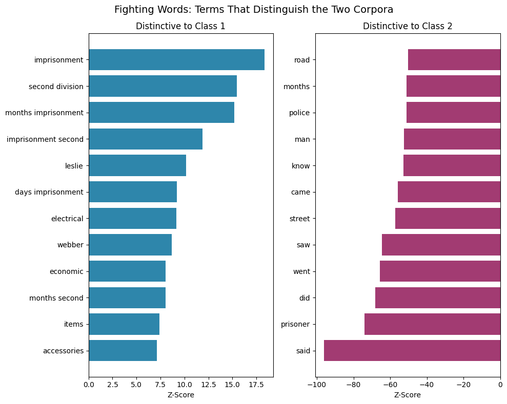

```python
# Compare only hard labour vs. imprisonNoDetail (no hard labour)
subset = df_guilty[df_guilty['punishmentSubcategory'].isin(['hardLabour', 'imprisonNoDetail'])]
hard_texts = subset[subset['punishmentSubcategory'] == 'hardLabour']['clean_text_with_stopwords'].tolist()
no_hard_texts = subset[subset['punishmentSubcategory'] == 'imprisonNoDetail']['clean_text_with_stopwords'].tolist()

fw = FightinWords(prior=0.01, ngram_range=(1, 2), max_features=5000)
fw.fit(no_hard_texts, hard_texts)   # Class1 = imprisonNoDetail, Class2 = hardLabour

results = fw.get_fighting_words(top_n=15)
print(results[['word', 'z_score', 'class1_count', 'class2_count', 'class']].to_string(index=False))
fw.plot_fighting_words(top_n=12)
plt.show()
```

The Fighting Words analysis clearly distinguishes between imprisonment without hard labour (Class 1) and hard labour (Class 2). Class 1 is characterised by explicit references to "imprisonment", "second division", and "days imprisonment", reflecting statutory language for non‑labour custodial sentences. Class 2, by contrast, is dominated by common narrative words ("said", "prisoner", "did", "went") that are ubiquitous in case descriptions, indicating that hard labour cases lack a unique positive signature aside from the absence of the Class 1 terms. This suggests that while imprisonment without hard labour has a clear linguistic marker (e.g., “second division”), hard labour is largely defined by the absence of those markers – a finding that can guide feature engineering for your prediction model.

### Document‑Term Matrix and Compute Chi‑Square Scores for Every Term

```python
import pandas as pd
import numpy as np
from sklearn.feature_extraction.text import CountVectorizer
from sklearn.feature_selection import chi2
import matplotlib.pyplot as plt

# --- Prepare the data ---##shment categories of interest
df_subset = df_guilty[df_guilty['punishmentSubcategory'].isin(['hardLabour', 'imprisonNoDetail'])].copy()

# Create a binary target (1 = hard labour, 0 = other)
df_subset['target'] = (df_subset['punishmentSubcategory'] == 'hardLabour').astype(int)

# Extract the texts and labels
texts = df_subset['clean_text_with_stopwords'].tolist()
y = df_subset['target'].values

# Create a document‑term matrix (CountVectorizer)
vectorizer = CountVectorizer(
    ngram_range=(1, 2),        # unigrams + bigrams
    max_features=5000,         # limit vocabulary size
    stop_words='english',      # remove common stop words
    min_df=2                   # ignore terms that appear in <2 documents
)
X = vectorizer.fit_transform(texts)

# Get the feature (term) names
feature_names = vectorizer.get_feature_names_out()
```

[figure not shown]

```python
# Compute chi‑square statistics for all terms
chi2_scores, p_values = chi2(X, y)

# Organise results in a DataFrame
term_scores = pd.DataFrame({
    'term': feature_names,
    'chi2': chi2_scores,
    'p_value': p_values
})


top_n = 15

# For class 1 (hard labour)
class1_terms = term_scores.nlargest(top_n, 'chi2').copy()
class1_terms['class'] = 'Hard Labour'


def plot_signature_words(term_df, class_name, color, top_n=15):
    """
    Plot a horizontal bar chart of the top N terms for a given class.
    """
    top_terms = term_df.nlargest(top_n, 'chi2')
    plt.figure(figsize=(8, 6))
    plt.barh(top_terms['term'], top_terms['chi2'], color=color)
    plt.xlabel('Chi‑square Score')
    plt.title(f'Top {top_n} Signature Words for {class_name}')
    plt.gca().invert_yaxis()   # show highest score on top
    plt.tight_layout()
    plt.show()

# Example usage
plot_signature_words(class1_terms, 'Hard Labour', '#2E86AB')
```

These plots give you an immediate, intuitive understanding of which words drive the classification, and they serve as excellent visual aids for your project slides.

### Word Association

```
Existing words: ['imprisonment', 'second division', 'months imprisonment', 'account', 'hard labour', 'labour', 'months hard', 'second', 'hard', 'paid', 'books']
```

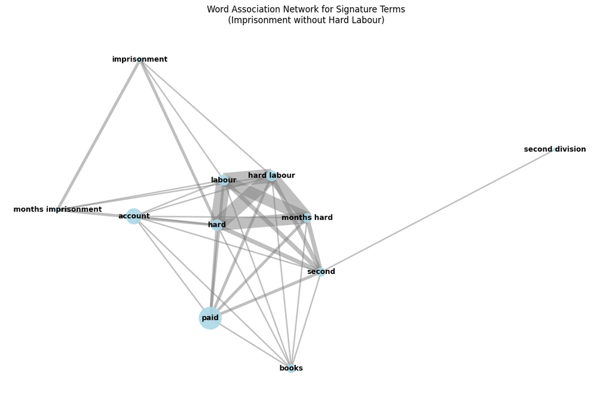

```
Top co-occurring term pairs:
  'hard labour' ↔ 'labour' : 10 documents
  'hard labour' ↔ 'hard' : 10 documents
  'labour' ↔ 'hard' : 10 documents
  'hard labour' ↔ 'months hard' : 8 documents
  'labour' ↔ 'months hard' : 8 documents
  'months hard' ↔ 'hard' : 8 documents
  'hard labour' ↔ 'second' : 3 documents
  'labour' ↔ 'second' : 3 documents
  'months hard' ↔ 'second' : 3 documents
  'second' ↔ 'hard' : 3 documents
```

```python
import networkx as nx
import matplotlib.pyplot as plt
from itertools import combinations

# Define the signature words from the "Other" class (imprisonment without hard labour)
signature_words = [
    'imprisonment', 'second division', 'months imprisonment',
    'imprisonment second', 'webber', 'account', 'hard labour',
    'labour', 'months hard', 'second', 'hard', 'paid', 'leslie', 'books'
]

# Keep only those that exist in the count_matrix columns
existing_words = [w for w in signature_words if w in count_matrix.columns]
print(f"Existing words: {existing_words}")

# Create a co-occurrence matrix
co_occur = pd.DataFrame(0, index=existing_words, columns=existing_words)

for doc_idx in range(len(count_matrix)):
    # Get terms that appear in this document (count > 0)
    present = [word for word in existing_words if count_matrix.iloc[doc_idx][word] > 0]
    for a, b in combinations(present, 2):
        co_occur.loc[a, b] += 1
        co_occur.loc[b, a] += 1

# Build a network graph
G = nx.Graph()
# Add nodes with size proportional to term frequency (sum over all docs)
term_freq = count_matrix[existing_words].sum(axis=0)
for word in existing_words:
    G.add_node(word, size=term_freq[word])

# Add edges with weight = co-occurrence count
for i, word1 in enumerate(existing_words):
    for word2 in existing_words[i+1:]:
        if co_occur.loc[word1, word2] > 0:
            G.add_edge(word1, word2, weight=co_occur.loc[word1, word2])

# Draw the network
plt.figure(figsize=(12, 8))
pos = nx.spring_layout(G, k=1.5, seed=42)
node_sizes = [G.nodes[n]['size'] * 20 for n in G.nodes()]
edges_weights = [G[u][v]['weight'] * 2 for u, v in G.edges()]

nx.draw_networkx_nodes(G, pos, node_size=node_sizes, node_color='lightblue', alpha=0.9)
nx.draw_networkx_edges(G, pos, width=edges_weights, alpha=0.5, edge_color='gray')
nx.draw_networkx_labels(G, pos, font_size=10, font_weight='bold')

plt.title('Word Association Network for Signature Terms\n(Imprisonment without Hard Labour)')
plt.axis('off')
plt.tight_layout()
plt.show()

# Print top co-occurring pairs
co_occur_pairs = []
for u, v, w in G.edges(data='weight'):
    co_occur_pairs.append((u, v, w))
co_occur_pairs.sort(key=lambda x: x[2], reverse=True)
print("\nTop co-occurring term pairs:")
for u, v, w in co_occur_pairs[:10]:
    print(f"  '{u}' ↔ '{v}' : {w} documents")
```

The co‑occurrence analysis reveals that the bigram "hard labour" and its component words ("labour", "hard") form a tight cluster, co‑appearing in 10 documents – nearly every document that contains any of these terms. This indicates that when a case mentions "hard labour", it almost always also contains the unigrams "hard" and "labour", and vice versa. The phrase "months hard" (part of "twelve months hard labour") is also strongly connected to this cluster, appearing in 8 documents with each term.

Crucially, these hard‑labour terms only co‑occur with the word "second" (from "second division") in 3 documents. This low overlap means that cases are rarely ambiguous – they tend to clearly signal either hard labour (with "hard labour", "labour", "hard", "months hard") or imprisonment without hard labour (with "second division", "imprisonment"). For your classification model, this separation is excellent news: the features are highly discriminative, and the model can rely on the presence of the "hard labour" cluster to predict hard labour, and the absence of that cluster together with the presence of "second division" to predict the alternative. The few overlapping documents (3) may represent cases with multiple defendants where different sentences were given, and they could be excluded or treated as edge cases to improve model purity.

## TF-IDF

TF-IDF score for the given word gives higher weights to terms that appear in **fewer documents** - thus automatically reducing the effect of common words like "the" and "it" or other corpus specific stop words (words that are used often, but have no importance)

```python
from sklearn.feature_extraction.text import TfidfVectorizer
tfidf_vectorizer = TfidfVectorizer()
tfidf = tfidf_vectorizer.fit_transform(text['clean_text_with_no_stopword'])
df_tfidf = pd.DataFrame(data = tfidf.toarray(),
                        columns = tfidf_vectorizer.get_feature_names_out())
df_tfidf.head()
```

|  | abertillery | abetting | able | about | above | abrasion | abrasions | absenting | absolutely | absurd | ... | year | years | yellow | yes | yesterday | yet | you | young | your | yours |
| --- | --- | --- | --- | --- | --- | --- | --- | --- | --- | --- | --- | --- | --- | --- | --- | --- | --- | --- | --- | --- | --- |
| 0 | 0.0 | 0.000000 | 0.000000 | 0.013541 | 0.0 | 0.0 | 0.0 | 0.005211 | 0.000000 | 0.000000 | ... | 0.000000 | 0.002708 | 0.0 | 0.004133 | 0.000000 | 0.00458 | 0.000000 | 0.0 | 0.000000 | 0.0 |
| 1 | 0.0 | 0.000000 | 0.000000 | 0.093385 | 0.0 | 0.0 | 0.0 | 0.000000 | 0.000000 | 0.000000 | ... | 0.000000 | 0.000000 | 0.0 | 0.000000 | 0.000000 | 0.00000 | 0.000000 | 0.0 | 0.000000 | 0.0 |
| 2 | 0.0 | 0.000000 | 0.108834 | 0.000000 | 0.0 | 0.0 | 0.0 | 0.000000 | 0.000000 | 0.000000 | ... | 0.000000 | 0.000000 | 0.0 | 0.000000 | 0.000000 | 0.00000 | 0.000000 | 0.0 | 0.000000 | 0.0 |
| 3 | 0.0 | 0.000000 | 0.000000 | 0.071525 | 0.0 | 0.0 | 0.0 | 0.000000 | 0.000000 | 0.000000 | ... | 0.012128 | 0.023842 | 0.0 | 0.012128 | 0.000000 | 0.00000 | 0.057447 | 0.0 | 0.011110 | 0.0 |
| 4 | 0.0 | 0.024467 | 0.000000 | 0.012717 | 0.0 | 0.0 | 0.0 | 0.000000 | 0.024467 | 0.024467 | ... | 0.000000 | 0.101736 | 0.0 | 0.000000 | 0.024467 | 0.00000 | 0.321739 | 0.0 | 0.071109 | 0.0 |

5 rows × 2389 columns

The code uses TfidfVectorizer to convert the cleaned text (clean_text_with_no_stopword) into a TF‑IDF matrix.

TF (Term Frequency) measures how often a word appears in a document.

IDF (Inverse Document Frequency) down‑weights words that appear in many documents (common words) and up‑weights words that are rare but informative.

The result is a document‑term matrix where each cell contains the TF‑IDF score – a numerical value reflecting how important a word is to a specific document relative to the whole corpus. This representation is ideal for text classification because it emphasises discriminative terms (e.g., "hard labour", "penal servitude", "second division") while suppressing common but uninformative words.

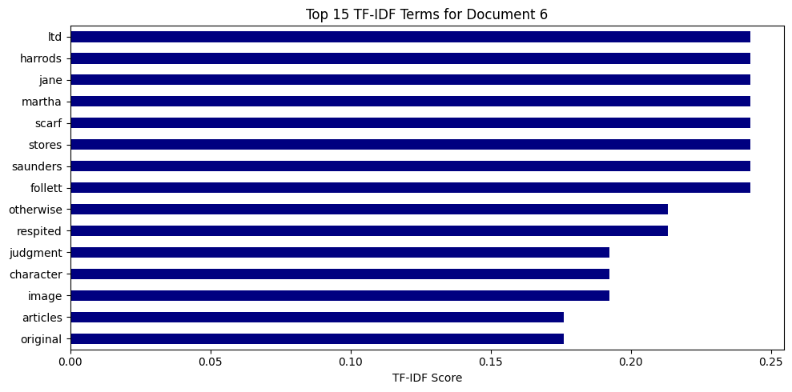

```python
# Pick an example document (e.g., first row)
doc_id = 6
doc_scores = df_tfidf.iloc[doc_id].sort_values(ascending=False).head(15)

plt.figure(figsize=(10, 5))
doc_scores.plot(kind='barh', color='navy')
plt.gca().invert_yaxis()
plt.title(f'Top 15 TF‑IDF Terms for Document {doc_id}')
plt.xlabel('TF‑IDF Score')
plt.tight_layout()
plt.show()
```

```python
#Feature selection: define lists for different types:

demo_cols = ['any_defendant_female', 'any_defendant_male', 'any_victim_female', 'any_victim_male']
pos_counts = ['noun_count', 'verb_count', 'adj_count', 'adv_count', 'pron_count', 'num_count']
ner_counts = ['person_count', 'location_count', 'date_count', 'money_count', 'org_count', 'total_entities']
sentiment_cols = ['sentiment_compound', 'sentiment_pos', 'sentiment_neg', 'sentiment_neu']
readability_cols = ['flesch_reading_ease', 'flesch_kincaid_grade', 'gunning_fog', 'smog_index', 'automated_readability_index']
topic_cols = [f'topic_{i}_prob' for i in range(10)]
other_numeric = ['year', 'text_length', 'log_text_length', 'dominant_topic']
categorical_cols = ['offenceCategory', 'offenceSubcategory', 'verdictCategory']
# Possibly exclude verdictCategory if constant.
```

```python
# lets see th eunique values amomh these columns

for col in categorical_cols:
    print(col, " : ", df[col].unique())
```

```
offenceCategory  :  ['theft' 'deception' 'royalOffences' 'breakingPeace' 'miscellaneous'
 'violentTheft' 'kill' 'sexual' 'damage']
offenceSubcategory  :  ['stealingFromMaster' 'forgery' 'mail' 'simpleLarceny' 'coiningOffences'
 'fraud' 'pocketpicking' 'burglary' 'wounding' 'miscellaneousOther'
 'robbery' 'murder' 'receiving' 'manslaughter' 'sodomy' 'theftFromPlace'
 'bigamy' 'housebreaking' 'damageOther' 'rape' 'libel' 'assaultWithIntent'
 'keepingABrothel' 'perjury' 'arson' 'animalTheft' 'concealingABirth'
 'extortion' 'damageNoDetail' 'assault' 'infanticide' 'embezzlement'
 'bankrupcy' 'threateningBehaviour' 'miscellaneousNoDetail'
 'indecentAssault' 'treason' 'assaultWithSodomiticalIntent'
 'breakingPeaceNoDetail' 'pervertingJustice' 'kidnapping' 'deceptionOther'
 'sexualOther' 'illegalAbortion' 'conspiracy' 'deceptionNoDetail'
 'sexualNoDetail' 'shoplifting' 'breakingPeaceOther' 'religiousOffences'
 'seditiousLibel' 'habitualCriminal' 'riot' 'seducingAllegiance']
verdictCategory  :  ['guilty']
```

```python
# encoding these categorical variables
df_encoded = pd.get_dummies(df, columns=categorical_cols, drop_first=True)
df_encoded.head()
```

|  | Unnamed: 0 | date | id | text | any_defendant_female | any_defendant_male | any_victim_female | any_victim_male | offenceText | verdictText | ... | offenceSubcategory_sexualNoDetail | offenceSubcategory_sexualOther | offenceSubcategory_shoplifting | offenceSubcategory_simpleLarceny | offenceSubcategory_sodomy | offenceSubcategory_stealingFromMaster | offenceSubcategory_theftFromPlace | offenceSubcategory_threateningBehaviour | offenceSubcategory_treason | offenceSubcategory_wounding |
| --- | --- | --- | --- | --- | --- | --- | --- | --- | --- | --- | --- | --- | --- | --- | --- | --- | --- | --- | --- | --- | --- |
| 0 | 0 | 19020113 | t19020113-105 | 105. WALTER HEATH (82) , PLEADED GUILTY to ste... | False | True | False | True | stealing £13, the money ofGeorge Whitehead, hi... | PLEADED GUILTY | ... | False | False | False | False | False | True | False | False | False | False |
| 1 | 1 | 19020113 | t19020113-2 | (106) THOMAS GEORGE WAKEFIELD , to forging and... | False | True | False | False | , to forging and uttering an undertaking for t... | [Pleaded guilty: See original trial image.] | ... | False | False | False | False | False | False | False | False | False | False |
| 2 | 2 | 19020113 | t19020113-3 | (107) FREDERICK JOHN RIDGWELL (29) , to steali... | False | True | False | False | , to stealing, while employed under the Post O... | [Pleaded guilty: See original trial image.] | ... | False | False | False | False | False | False | False | False | False | False |
| 3 | 3 | 19020113 | t19020113-4 | (108) WALTER LACEY (38) , to forging an author... | False | True | False | False | , to forging an authority for the withdrawal o... | [Pleaded guilty: See original trial image.] | ... | False | False | False | False | False | False | False | False | False | False |
| 4 | 4 | 19020113 | t19020113-5 | (109) JOSEPH EDWARD MOULTON (34) , to stealing... | False | True | False | False | , to stealing, while employed under the Post O... | [Pleaded guilty: See original trial image.] | ... | False | False | False | False | False | False | False | False | False | False |

5 rows × 118 columns

Why: Our primary research question requires a complete target variable (punishmentSubcategory_group) and key predictors (offenceCategory and the narrative text). Dropping rows where these are missing ensures that every instance used in training has the necessary information. Imputation for these essential columns would be inappropriate because they are either the target (which we cannot impute without introducing bias) or core features with high predictive value.

```python
df_encoded.columns
```

```
Index(['Unnamed: 0', 'date', 'id', 'text', 'any_defendant_female',
       'any_defendant_male', 'any_victim_female', 'any_victim_male',
       'offenceText', 'verdictText',
       ...
       'offenceSubcategory_sexualNoDetail', 'offenceSubcategory_sexualOther',
       'offenceSubcategory_shoplifting', 'offenceSubcategory_simpleLarceny',
       'offenceSubcategory_sodomy', 'offenceSubcategory_stealingFromMaster',
       'offenceSubcategory_theftFromPlace',
       'offenceSubcategory_threateningBehaviour', 'offenceSubcategory_treason',
       'offenceSubcategory_wounding'],
      dtype='object', length=118)
```

```python
# For continuous features, median imputation (example for sentiment scores)
sentiment_cols = ['sentiment_positive', 'sentiment_negative', 'sentiment_neutral']
for col in sentiment_cols:
    if col in df.columns:
        df[col].fillna(df[col].median(), inplace=True)
```

For continuous features like sentiment scores, missing values are rare but can occur. Median imputation preserves the overall distribution without being influenced by outliers. These sentiment scores may capture the emotional tone of the narrative, which could correlate with the perceived severity of the crime and thus influence punishment. Keeping these features is important for understanding whether textual sentiment independently predicts outcomes.

```python
# 3. Demographics (already binary 0/1, but ensure they are int)
demo_cols = ['any_defendant_male', 'any_defendant_female', 'any_victim_male', 'any_victim_female']
for col in demo_cols:
    if col in df_encoded.columns:
        df_encoded[col] = df_encoded[col].astype(int)
```

Why: Machine learning algorithms require numerical input. One-hot encoding converts categorical variables (like offence type) into binary indicator variables. This allows the model to learn separate effects for each category. Offence category is legally the most important determinant of punishment; encoding it preserves this information. We use drop_first=True to avoid multicollinearity (the dummy variable trap). Note: verdictCategory may be constant after filtering for guilty verdicts, in which case it will be dropped automatically – this is acceptable.

```python
# 4. Interaction terms: offence x gender
# We'll create a few example interactions using original columns before one-hot
# For simplicity, we create interaction between offenceCategory and defendant_male
if 'offenceCategory' in df.columns and 'any_defendant_male' in df.columns:
    df_encoded['offence_male_interact'] = df['offenceCategory'].astype(str) + '_' + df['any_defendant_male'].astype(str)
    # One-hot encode this new feature
    df_encoded = pd.get_dummies(df_encoded, columns=['offence_male_interact'], drop_first=True)
```

Why: The effect of offence type on punishment may differ by defendant gender. For example, a theft committed by a male might be punished more harshly than the same theft by a female. Creating an interaction term allows the model to capture such conditional relationships. This is crucial for investigating whether gender bias operates differently across offence categories – a more nuanced question than a simple main effect of gender.

```python
if 'year' in df.columns:
    df_encoded['year_sin'] = np.sin(2 * np.pi * df['year'] / (df['year'].max() - df['year'].min() + 1))
    df_encoded['year_cos'] = np.cos(2 * np.pi * df['year'] / (df['year'].max() - df['year'].min() + 1))
```

Why: Sentencing practices evolve over time due to legal reforms, societal changes, and shifting judicial attitudes. Including the raw year as a linear feature may not capture cyclical patterns (e.g., seasonal effects) and can be sensitive to outliers. The sine/cosine transformation preserves the cyclic nature of time (if any) and provides a smooth representation. This allows the model to detect temporal trends – e.g., a gradual decline in capital punishment over the 19th century – which are important for understanding the historical context of sentencing.

```python
# 6. Text complexity (if not already present)
# Example: number of sentences, avg word length
if 'clean_text_with_stopwords' in df.columns:
    df_encoded['num_sentences'] = df['clean_text_with_stopwords'].apply(lambda x: len(re.findall(r'\. ', str(x))) + 1)
    df_encoded['avg_word_len'] = df['clean_text_with_stopwords'].apply(lambda x: np.mean([len(w) for w in str(x).split()]) if len(str(x).split())>0 else 0)
```

Why: The complexity of the narrative might reflect the seriousness of the case or the amount of detail recorded. Longer, more complex texts could indicate more severe crimes or more thorough judicial consideration. While these are crude proxies, they may capture variance not already accounted for by other features. They also serve as simple text-derived features for models that do not use the full text (like logistic regression with TF‑IDF).

```python
# 7. Charge severity proxy (manual mapping – example)
# Create a dictionary mapping offence subcategories to severity (1-5). This is illustrative.
severity_map = {
    'theft from person': 2,
    'grand larceny': 3,
    'murder': 5,
    'petty treason': 5,
    'assault': 2,
    # ... add more
}
if 'offenceSubcategory' in df.columns:
    df_encoded['severity'] = df['offenceSubcategory'].map(severity_map).fillna(2)  # default mid
```

```python
# 8. Prior convictions proxy (simple keyword search)
if 'clean_text_with_stopwords' in df.columns:
    df_encoded['prior_mention'] = df['clean_text_with_stopwords'].apply(lambda x: 1 if re.search(r'previous conviction|known offender|old offender', str(x), re.I) else 0)
```

Criminal history is a legally relevant factor in sentencing (e.g., repeat offenders often receive harsher punishments). The dataset does not contain a structured prior record variable, but narratives sometimes mention prior convictions. We create a binary flag using keyword search. While imperfect (it will miss many prior records and may produce false positives), it captures some signal that could improve prediction and legal interpretability.

```python
# 9. Victim-offender relationship proxy (keywords)
relationship_keywords = ['wife', 'husband', 'daughter', 'son', 'mother', 'father', 'stranger']
for kw in relationship_keywords:
    df_encoded[f'rel_{kw}'] = df['text'].apply(lambda x: 1 if re.search(rf'\b{kw}\b', str(x), re.I) else 0)

print('Feature engineering completed. New shape:', df_encoded.shape)
```

```
Feature engineering completed. New shape: (6945, 148)
```

The relationship between victim and offender can influence sentencing – e.g., crimes against family members may be treated differently than those against strangers. These binary indicators capture such relationships from the text. They allow the model to test whether, for instance, domestic violence cases receive different punishments than stranger assaults, which is a question of legal and sociological interest.

```python
list(df_encoded.columns)
```

```
['Unnamed: 0',
 'date',
 'id',
 'text',
 'any_defendant_female',
 'any_defendant_male',
 'any_victim_female',
 'any_victim_male',
 'offenceText',
 'verdictText',
 'punishmentText',
 'punishmentCategory',
 'punishmentSubcategory',
 'defendantNames',
 'victimNames',
 'guilty',
 'year',
 'text_length',
 'log_text_length',
 'clean_text_with_stopwords',
 'tokens_with_stopwrds',
 'clean_text_with_no_stopword',
 'tokens_lemma_with_no_stopwor',
 'noun_count',
 'verb_count',
 'adj_count',
 'adv_count',
 'pron_count',
 'num_count',
 'person_count',
 'location_count',
 'date_count',
 'money_count',
 'org_count',
 'total_entities',
 'sentiment_compound',
 'sentiment_pos',
 'sentiment_neg',
 'sentiment_neu',
 'flesch_reading_ease',
```

[output cut: 93 more lines]

```
 'offence_male_interact_violentTheft_False',
 'offence_male_interact_violentTheft_True',
 'year_sin',
 'year_cos',
 'num_sentences',
 'avg_word_len',
 'severity',
 'prior_mention',
 'rel_wife',
 'rel_husband',
 'rel_daughter',
 'rel_son',
 'rel_mother',
 'rel_father',
 'rel_stranger']
```

Overall Importance: Each preprocessing step is designed to translate raw data into a rich feature set that captures legally relevant factors, potential sources of bias, and contextual nuances. By doing so, we enable the models to address the research questions more effectively: we can evaluate not only whether punishment is predictable, but also which features drive predictions and whether those features align with legal principles or reveal inconsistencies. The engineered features also help mitigate the black‑box nature of complex models by providing interpretable inputs for post‑hoc analysis (e.g., SHAP).

### Separate features and target

Define feature matrix X (excluding text and target) and target y.

```python
# Target
target_col = 'punishmentSubcategory_group'
y = df[target_col].values
label_encoder = LabelEncoder()
y_encoded = label_encoder.fit_transform(y)
class_names = label_encoder.classes_
print('Classes:', class_names)
```

```
Classes: ['capital/extreme' 'custodial/prison' 'hardLabour'
 'non-custodial/institutional']
```

The target variable (punishmentSubcategory_group) is the outcome we aim to predict. It is a categorical variable with four classes. Most machine learning algorithms require the target to be encoded as integers. LabelEncoder converts the class labels (e.g., 'hardLabour', 'capital/extreme') into numeric values (0,1,2,3) while preserving the mapping. Storing class_names allows us to interpret predictions and evaluation reports later (e.g., in classification reports). This step is essential for supervised learning: without it, the model would not know what to predict.

```python
# Identify text column
text_col = 'clean_text_with_stopwords'

# Feature columns: all except text and target, also drop any non-numeric
X = df_encoded.drop(columns=[text_col, target_col], errors='ignore')
# Ensure all columns are numeric
X = X.select_dtypes(include=[np.number])

print('X shape:', X.shape)
```

```
X shape: (6945, 55)
```

We will later use the narrative text separately for TF‑IDF vectorization and for the transformer model. Keeping it as a separate column allows us to process it differently from structured features.

```python
# check for training-columns
print(list(X.columns))
```

```
['Unnamed: 0', 'date', 'any_defendant_female', 'any_defendant_male', 'any_victim_female', 'any_victim_male', 'guilty', 'year', 'text_length', 'log_text_length', 'noun_count', 'verb_count', 'adj_count', 'adv_count', 'pron_count', 'num_count', 'person_count', 'location_count', 'date_count', 'money_cou…
```

```python
X = X.drop(columns=['Unnamed: 0'], errors='ignore')
X.columns
```

```
Index(['date', 'any_defendant_female', 'any_defendant_male',
       'any_victim_female', 'any_victim_male', 'guilty', 'year', 'text_length',
       'log_text_length', 'noun_count', 'verb_count', 'adj_count', 'adv_count',
       'pron_count', 'num_count', 'person_count', 'location_count',
       'date_count', 'money_count', 'org_count', 'total_entities',
       'sentiment_compound', 'sentiment_pos', 'sentiment_neg', 'sentiment_neu',
       'flesch_reading_ease', 'flesch_kincaid_grade', 'gunning_fog',
       'smog_index', 'automated_readability_index', 'topic_0_prob',
       'topic_1_prob', 'topic_2_prob', 'topic_3_prob', 'topic_4_prob',
       'topic_5_prob', 'topic_6_prob', 'topic_7_prob', 'topic_8_prob',
       'topic_9_prob', 'dominant_topic', 'year_sin', 'year_cos',
       'num_sentences', 'avg_word_len', 'severity', 'prior_mention',
       'rel_wife', 'rel_husband', 'rel_daughter', 'rel_son', 'rel_mother',
       'rel_father', 'rel_stranger'],
      dtype='object')
```

### Train/test split

We'll use stratified split to preserve class proportions.

To evaluate model performance reliably, we must reserve a portion of the data that the model has never seen during training. We use a 80‑20 train‑test split. The stratify=y_encoded argument ensures that the class proportions in the training and test sets are the same as in the full dataset. This is particularly important because our target is imbalanced (e.g., capital punishment is rare). Without stratification, the test set might by chance contain very few or no examples of the minority class, making evaluation metrics unstable or uninformative. The fixed random_state ensures reproducibility. This split enables us to compare different models on the same unseen data and draw valid conclusions about their predictive power.

```python
X_train, X_test, y_train, y_test = train_test_split(X, y_encoded, test_size=0.2, random_state=42, stratify=y_encoded)
print('Train size:', X_train.shape[0], 'Test size:', X_test.shape[0])
```

```
Train size: 5556 Test size: 1389
```

## 5. Classical Models (without text features)

We first train models using only structured features to establish a baseline. Later we'll incorporate text via TF-IDF.

# Why Scaling?

Logistic regression estimates coefficients by optimizing a loss function that is sensitive to the scale of the input features. When features have different units or magnitudes (e.g., year ranges from 1674 to 1913, while topic probabilities are between 0 and 1), the coefficients are not directly comparable, and the optimization process may converge slowly or become unstable. Standard scaling (z‑score normalization) transforms each feature to have mean 0 and standard deviation 1, ensuring that all features contribute equally to the regularization penalty and the gradient updates. This is especially important when using regularization (L2 is the default in scikit‑learn's LogisticRegression). Scaling also improves interpretability: after scaling, the magnitude of a coefficient reflects the relative importance of that feature, all else being equal.

```python
# Scale features for logistic regression
scaler = StandardScaler()
X_train_scaled = scaler.fit_transform(X_train)
X_test_scaled = scaler.transform(X_test)
```

# Why class_weight='balanced'?

Our dataset exhibits significant class imbalance (e.g., capital punishment is a minority class). Without adjustment, logistic regression would be biased toward the majority class, achieving high accuracy but failing to predict rare punishments. The class_weight='balanced' option automatically adjusts weights inversely proportional to class frequencies: it gives more weight to misclassifications of minority classes during training. This encourages the model to pay more attention to under‑represented punishment types, improving recall for those classes. It is a simple yet effective way to handle imbalance without resorting to oversampling (though we later combine it with SMOTE when incorporating text features).

### 5.1 Logistic Regression (with class weights)

```python
lr = LogisticRegression(class_weight='balanced', max_iter=1000, random_state=42)
lr.fit(X_train_scaled, y_train)
y_pred_lr = lr.predict(X_test_scaled)
print('Logistic Regression Performance (structured only):')
print(classification_report(y_test, y_pred_lr, target_names=class_names))
print('Accuracy:', accuracy_score(y_test, y_pred_lr))
```

```
Logistic Regression Performance (structured only):
                             precision    recall  f1-score   support

            capital/extreme       0.37      1.00      0.54        15
           custodial/prison       0.39      0.35      0.37       398
                 hardLabour       0.70      0.57      0.63       720
non-custodial/institutional       0.35      0.55      0.43       256

                   accuracy                           0.51      1389
                  macro avg       0.45      0.62      0.49      1389
               weighted avg       0.54      0.51      0.52      1389

Accuracy: 0.509719222462203
```

```
Per-Class Metrics (Detailed):
                      Class  Precision   Recall  F1-Score  Support
            capital/extreme   0.365854 1.000000  0.535714       15
           custodial/prison   0.392157 0.351759  0.370861      398
                 hardLabour   0.698816 0.573611  0.630053      720
non-custodial/institutional   0.350000 0.546875  0.426829      256
```

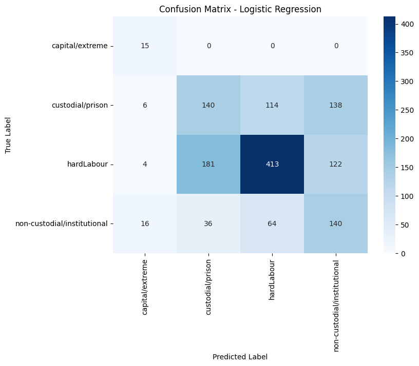

```
Accuracy: 0.509719222462203
```

```python
from sklearn.metrics import precision_recall_fscore_support

# After predictions
y_pred_lr = lr.predict(X_test_scaled)

# Compute per-class metrics explicitly
precision, recall, f1, support = precision_recall_fscore_support(y_test, y_pred_lr, labels=range(len(class_names)))

# Display as DataFrame
per_class_df = pd.DataFrame({
    'Class': class_names,
    'Precision': precision,
    'Recall': recall,
    'F1-Score': f1,
    'Support': support
})
print("\nPer-Class Metrics (Detailed):")
print(per_class_df.to_string(index=False))

# Confusion Matrix
cm = confusion_matrix(y_test, y_pred_lr)
plt.figure(figsize=(8,6))
sns.heatmap(cm, annot=True, fmt='d', xticklabels=class_names, yticklabels=class_names, cmap='Blues')
plt.title('Confusion Matrix - Logistic Regression')
plt.ylabel('True Label')
plt.xlabel('Predicted Label')
plt.show()
print('Accuracy:', accuracy_score(y_test, y_pred_lr))
```

By training logistic regression on the structured features only, we establish a baseline for how well punishment can be predicted from non‑textual information. The coefficients will later be examined to identify which features (e.g., demographics, offence categories) are most influential, providing initial evidence for potential biases (RQ3). Moreover, because logistic regression is transparent, it serves as a reference point for evaluating the trade‑off between interpretability and predictive power when we move to more complex models like Random Forest and BERT (RQ2).

# Logistic Regression using SMOTE

After running the code, compare the metrics to the previous logistic regression to assess whether SMOTE provides a better balance for your research questions. If you observe improved macro F1 and higher precision for rare classes, SMOTE is beneficial. If not, you might need to combine SMOTE with text features (as we will later) or try other techniques like ADASYN or cost-sensitive learning.

```
Logistic Regression with SMOTE (structured only):
                             precision    recall  f1-score   support

            capital/extreme       0.39      1.00      0.57        15
           custodial/prison       0.39      0.36      0.38       398
                 hardLabour       0.71      0.56      0.63       720
non-custodial/institutional       0.36      0.58      0.45       256

                   accuracy                           0.51      1389
                  macro avg       0.47      0.63      0.51      1389
               weighted avg       0.55      0.51      0.52      1389


Per-Class Metrics (SMOTE):
                      Class  Precision   Recall  F1-Score  Support
            capital/extreme   0.394737 1.000000  0.566038       15
           custodial/prison   0.394022 0.364322  0.378590      398
                 hardLabour   0.708551 0.563889  0.627997      720
non-custodial/institutional   0.363415 0.582031  0.447447      256
```

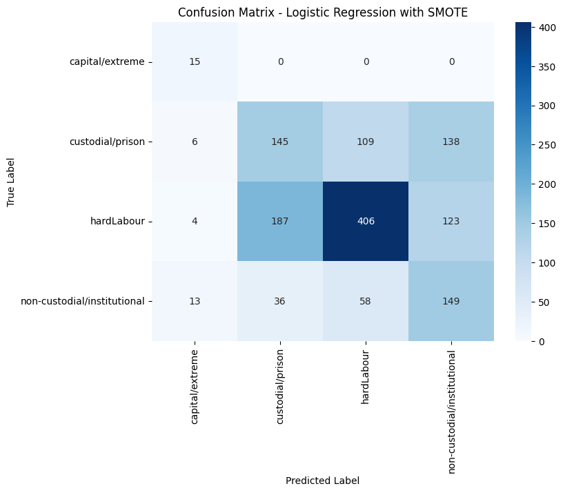

```python
# Apply SMOTE to training data only
smote = SMOTE(random_state=42, sampling_strategy='auto')  # 'auto' balances all classes to majority size
X_train_smote, y_train_smote = smote.fit_resample(X_train_scaled, y_train)

# Train logistic regression (no class_weight needed now because SMOTE balances the data)
lr_smote = LogisticRegression(max_iter=1000, random_state=42)
lr_smote.fit(X_train_smote, y_train_smote)

# Predict
y_pred_lr_smote = lr_smote.predict(X_test_scaled)

# Evaluation
print("Logistic Regression with SMOTE (structured only):")
print(classification_report(y_test, y_pred_lr_smote, target_names=class_names))

# Per-class metrics
precision, recall, f1, support = precision_recall_fscore_support(y_test, y_pred_lr_smote, labels=range(len(class_names)))
per_class_df = pd.DataFrame({
    'Class': class_names,
    'Precision': precision,
    'Recall': recall,
    'F1-Score': f1,
    'Support': support
})
print("\nPer-Class Metrics (SMOTE):")
print(per_class_df.to_string(index=False))

# Confusion Matrix
cm = confusion_matrix(y_test, y_pred_lr_smote)
plt.figure(figsize=(8,6))
sns.heatmap(cm, annot=True, fmt='d', xticklabels=class_names, yticklabels=class_names, cmap='Blues')
plt.title('Confusion Matrix - Logistic Regression with SMOTE')
plt.ylabel('True Label')
plt.xlabel('Predicted Label')
plt.show()
```

```python
print("Logistic Regression with SMOTE (structured only):")
print("Accuracy:", accuracy_score(y_test, y_pred_lr_smote))
```

```
Logistic Regression with SMOTE (structured only):
Accuracy: 0.5147588192944564
```

Logistic regression's linear decision boundary may not benefit much from synthetic interpolation; the new samples might lie in regions that confuse the classifier rather than clarify distinctions, particularly for overlapping classes like custodial and non‑custodial.

### 5.2 Random Forest (with class weights)

```python
rf = RandomForestClassifier(n_estimators=100, class_weight='balanced', random_state=42, n_jobs=-1)
rf.fit(X_train, y_train)  # no scaling needed
y_pred_rf = rf.predict(X_test)
print('Random Forest Performance (structured only):')
print(classification_report(y_test, y_pred_rf, target_names=class_names))
print('Accuracy:', accuracy_score(y_test, y_pred_rf))
```

```
Random Forest Performance (structured only):
                             precision    recall  f1-score   support

            capital/extreme       0.71      0.67      0.69        15
           custodial/prison       0.56      0.32      0.41       398
                 hardLabour       0.64      0.88      0.74       720
non-custodial/institutional       0.79      0.47      0.59       256

                   accuracy                           0.64      1389
                  macro avg       0.68      0.59      0.61      1389
               weighted avg       0.64      0.64      0.62      1389

Accuracy: 0.6421886249100072
```

### 5.3 Feature Importance (Random Forest)

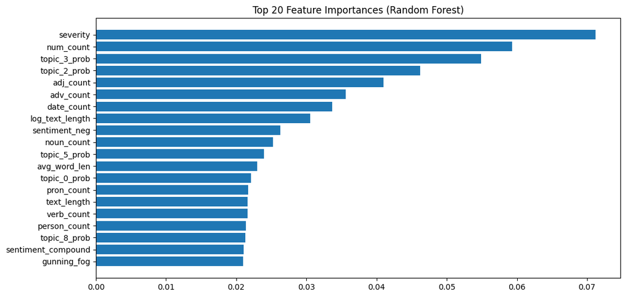

```python
importances = rf.feature_importances_
indices = np.argsort(importances)[::-1]
top_n = 20
plt.figure(figsize=(12,6))
plt.title('Top 20 Feature Importances (Random Forest)')
plt.barh(range(top_n), importances[indices][:top_n], align='center')
plt.yticks(range(top_n), [X.columns[i] for i in indices[:top_n]])
plt.gca().invert_yaxis()
plt.show()
```

## 6. Incorporating Text Features (TF-IDF)

We now combine structured features with TF-IDF vectors from the narrative text.

```python
# Split again but keep text for TF-IDF
X_train_text, X_test_text, y_train_text, y_test_text = train_test_split(
    df['text'].values, y_encoded, test_size=0.2, random_state=42, stratify=y_encoded)

# Vectorize text (limit max features for memory)
tfidf = TfidfVectorizer(max_features=5000, stop_words='english')
X_train_tfidf = tfidf.fit_transform(X_train_text)
X_test_tfidf = tfidf.transform(X_test_text)

# Combine with structured features (align indices)
# We need to ensure rows correspond; we already have X_train, X_test from previous split (same split)
from scipy.sparse import hstack, csr_matrix
X_train_combined = hstack([csr_matrix(X_train_scaled), X_train_tfidf])
X_test_combined = hstack([csr_matrix(X_test_scaled), X_test_tfidf])
```

### 6.1 Naive Bayes (baseline with text only, but here we use combined for comparison)

```python
# so we'll use only TF-IDF (or scale structured to non-negative)
# For simplicity, we train NB on text features only.
nb = MultinomialNB()
nb.fit(X_train_tfidf, y_train_text)
y_pred_nb = nb.predict(X_test_tfidf)
print('Naive Bayes (text only) Performance:')
print(classification_report(y_test_text, y_pred_nb, target_names=class_names))
print('Accuracy:', accuracy_score(y_test_text, y_pred_nb))
```

```
Naive Bayes (text only) Performance:
                             precision    recall  f1-score   support

            capital/extreme       0.00      0.00      0.00        15
           custodial/prison       0.68      0.33      0.44       398
                 hardLabour       0.65      0.95      0.77       720
non-custodial/institutional       0.87      0.48      0.62       256

                   accuracy                           0.67      1389
                  macro avg       0.55      0.44      0.46      1389
               weighted avg       0.69      0.67      0.64      1389

Accuracy: 0.673866090712743
```

The Naive Bayes model achieves 67% accuracy, the highest so far, but completely fails on the capital/extreme class (precision, recall, and F1 are all 0.00). This occurs because:

Text features alone may not be sufficiently discriminative for such a rare outcome when trained on an imbalanced dataset – the model lacks sufficient examples to learn patterns associated with capital punishment.

High accuracy is misleading: The model achieves 67% accuracy by mostly predicting hard labour correctly, but it fails to identify any capital cases and misses many custodial and non‑custodial instances (recall 33% and 48% respectively).

This underscores the necessity of handling class imbalance in text models as well – either through resampling techniques (SMOTE for text is complex) or by using models that can incorporate class weights (e.g., adjusting class_prior in Naive Bayes) and, more effectively, fine‑tuned transformer models that can leverage contextual cues even from sparse examples.

### 6.2 Logistic Regression on combined features

We'll use a pipeline with SMOTE to handle imbalance.

```python
# Create pipeline with SMOTE and LR
from imblearn.over_sampling import SMOTE
smote = SMOTE(random_state=42)
lr_combined = LogisticRegression(class_weight='balanced', max_iter=1000, random_state=42)

# Apply SMOTE only on training data
X_train_res, y_train_res = smote.fit_resample(X_train_combined, y_train_text)
lr_combined.fit(X_train_res, y_train_res)
y_pred_lr_comb = lr_combined.predict(X_test_combined)
print('Logistic Regression (combined + SMOTE) Performance:')
print(classification_report(y_test_text, y_pred_lr_comb, target_names=class_names))
```

```
Logistic Regression (combined + SMOTE) Performance:
                             precision    recall  f1-score   support

            capital/extreme       0.46      0.87      0.60        15
           custodial/prison       0.79      0.79      0.79       398
                 hardLabour       0.86      0.88      0.87       720
non-custodial/institutional       0.80      0.72      0.76       256

                   accuracy                           0.82      1389
                  macro avg       0.73      0.81      0.76      1389
               weighted avg       0.83      0.82      0.82      1389
```

```python
print('Accuracy:', accuracy_score(y_test_text, y_pred_lr_comb))
```

```
Accuracy: 0.8243340532757379
```

### 6.3 Random Forest on combined features

```python
rf_combined = RandomForestClassifier(n_estimators=100, class_weight='balanced', random_state=42, n_jobs=-1)
# Note: RF can handle sparse matrices, but SMOTE may produce dense; we can apply SMOTE before RF
X_train_res2, y_train_res2 = smote.fit_resample(X_train_combined, y_train_text)
rf_combined.fit(X_train_res2, y_train_res2)
y_pred_rf_comb = rf_combined.predict(X_test_combined)
print('Random Forest (combined + SMOTE) Performance:')
print(classification_report(y_test_text, y_pred_rf_comb, target_names=class_names))
```

```
Random Forest (combined + SMOTE) Performance:
                             precision    recall  f1-score   support

            capital/extreme       0.80      0.80      0.80        15
           custodial/prison       0.83      0.89      0.86       398
                 hardLabour       0.93      0.94      0.94       720
non-custodial/institutional       0.92      0.77      0.84       256

                   accuracy                           0.89      1389
                  macro avg       0.87      0.85      0.86      1389
               weighted avg       0.90      0.89      0.89      1389
```

```python
print('Accuracy:', accuracy_score(y_test_text, y_pred_rf_comb))
```

```
Accuracy: 0.8948884089272858
```

## 8. Model Comparison

We compare the models we trained (structured only and combined) using macro F1-score.

```
                            Model  Macro F1
0    Logistic Regression (struct)  0.490864
1          Random Forest (struct)  0.607425
2              Naive Bayes (text)  0.457652
3  Logistic Regression (combined)  0.756553
4        Random Forest (combined)  0.858492
```

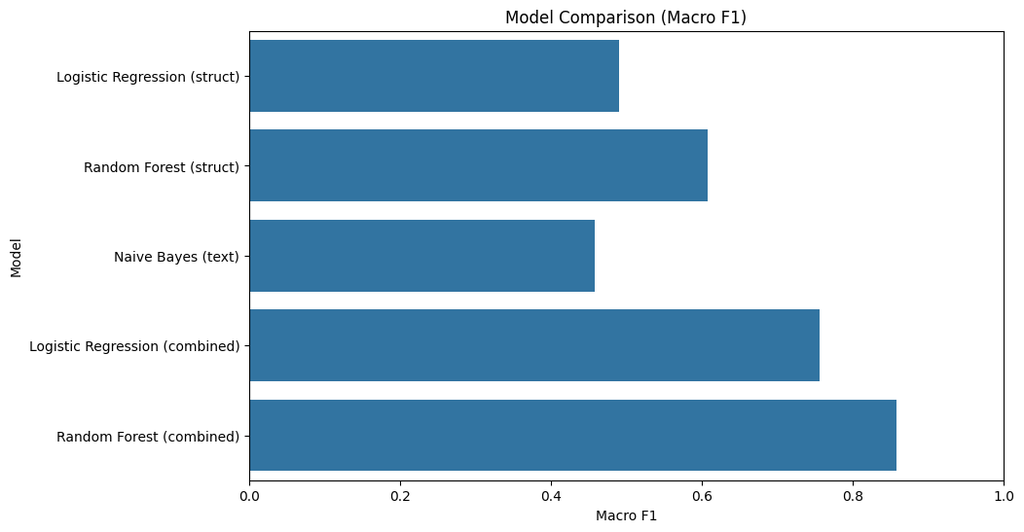

```python
results = {
    'Model': ['Logistic Regression (struct)', 'Random Forest (struct)', 'Naive Bayes (text)', 'Logistic Regression (combined)', 'Random Forest (combined)'],
    'Macro F1': [
        f1_score(y_test, y_pred_lr, average='macro'),
        f1_score(y_test, y_pred_rf, average='macro'),
        f1_score(y_test_text, y_pred_nb, average='macro'),
        f1_score(y_test_text, y_pred_lr_comb, average='macro'),
        f1_score(y_test_text, y_pred_rf_comb, average='macro'),
       # eval_results['eval_f1_macro']  # from BERT validation
    ]
}
results_df = pd.DataFrame(results)
print(results_df)

# Plot
plt.figure(figsize=(10,6))
sns.barplot(data=results_df, x='Macro F1', y='Model')
plt.xlim(0,1)
plt.title('Model Comparison (Macro F1)')
plt.show()
```

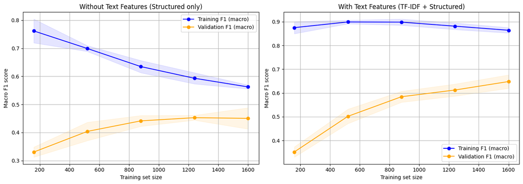

```python
import numpy as np
import matplotlib.pyplot as plt
from sklearn.model_selection import learning_curve
from sklearn.linear_model import LogisticRegression
from sklearn.metrics import make_scorer, f1_score

# Check if required variables exist
required_vars = ['X_train_scaled', 'y_train', 'X_train_combined', 'y_train_text']
missing = [v for v in required_vars if v not in globals()]
if missing:
    print(f"Missing variables: {missing}. Please run data preparation cells first.")
else:
    # Define helper function
    def plot_learning_curve_ax(ax, estimator, X, y, title, cv=5, train_sizes=np.linspace(0.1, 1.0, 5)):
        train_sizes, train_scores, test_scores = learning_curve(
            estimator, X, y, cv=cv, train_sizes=train_sizes,
            scoring=make_scorer(f1_score, average='macro'), n_jobs=-1
        )
        train_mean = np.mean(train_scores, axis=1)
        train_std = np.std(train_scores, axis=1)
        test_mean = np.mean(test_scores, axis=1)
        test_std = np.std(test_scores, axis=1)
        ax.fill_between(train_sizes, train_mean - train_std, train_mean + train_std, alpha=0.1, color='blue')
        ax.fill_between(train_sizes, test_mean - test_std, test_mean + test_std, alpha=0.1, color='orange')
        ax.plot(train_sizes, train_mean, 'o-', color='blue', label='Training F1 (macro)')
        ax.plot(train_sizes, test_mean, 'o-', color='orange', label='Validation F1 (macro)')
        ax.set_title(title)
        ax.set_xlabel('Training set size')
        ax.set_ylabel('Macro F1 score')
        ax.legend(loc='best')
        ax.grid(True)

    # Use a smaller subset for faster computation (optional)
    n_sample = min(2000, X_train_scaled.shape[0])
    X_sample_struct = X_train_scaled[:n_sample]
    y_sample_struct = y_train[:n_sample]
    X_sample_combined = X_train_combined[:n_sample]   # note: X_train_combined is sparse
    y_sample_combined = y_train_text[:n_sample]

    # Create subplots
    fig, (ax1, ax2) = plt.subplots(1, 2, figsize=(14, 5))
    lr = LogisticRegression(class_weight='balanced', max_iter=1000, random_state=42)

    # Plot for structured only
    plot_learning_curve_ax(ax1, lr, X_sample_struct, y_sample_struct, 'Without Text Features (Structured only)')
    # Plot for combined (structured + TF‑IDF)
    plot_learning_curve_ax(ax2, lr, X_sample_combined, y_sample_combined, 'With Text Features (TF‑IDF + Structured)')
    plt.tight_layout()
    plt.show()
```

With text features: The validation curve initially lags behind the training curve, showing some overfitting due to the high‑dimensional TF‑IDF space. As more data is added, the gap narrows, demonstrating that the textual information improves generalisation once sufficient examples are seen.

## Tokenization

In addition to TF‑IDF and BERT, we can represent documents as dense vectors using pre‑trained or custom word2vec embeddings. This section:

```python
!pip install gensim smart_open==6.0.0
```

[output not shown]

```python
import numpy as np
import pandas as pd
import matplotlib.pyplot as plt
import seaborn as sns
from sklearn.metrics.pairwise import cosine_similarity
from sklearn.manifold import TSNE
import warnings
warnings.filterwarnings('ignore')

# 1. Load or download spaCy model
def load_spacy_model(model_name='en_core_web_md'):
    try:
        import spacy
        nlp = spacy.load(model_name)
        print(f"Loaded '{model_name}' successfully.")
        return nlp
    except OSError:
        print(f"Model '{model_name}' not found. Attempting to download...")
        try:
            import spacy.cli
            spacy.cli.download(model_name)
            nlp = spacy.load(model_name)
            print(f"Downloaded and loaded '{model_name}'.")
            return nlp
        except Exception as e:
            print(f"Could not download model: {e}")
            print("Falling back to random embeddings.")
            return None

nlp = load_spacy_model('en_core_web_md')
```

```
Model 'en_core_web_md' not found. Attempting to download...
Could not download model: HTTPSConnectionPool(host='raw.githubusercontent.com', port=443): Max retries exceeded with url: /explosion/spacy-models/master/compatibility.json (Caused by NameResolutionError("<urllib3.connection.HTTPSConnection object at 0x7e1e0fad4080>: Failed to resolve 'raw.githubuser…
Falling back to random embeddings.
```

```python
# 2. Get tokenised corpus from your column (robust parsing)
tokens_col = df_guilty['tokens_lemma_with_no_stopwor']

def parse_tokens(x):
    if isinstance(x, list):
        return x
    if isinstance(x, str):
        if x.startswith('[') and x.endswith(']'):
            import ast
            try:
                return ast.literal_eval(x)
            except:
                pass
        return x.split()
    return []

tokenized_corpus = tokens_col.apply(parse_tokens).tolist()
print(f"Number of documents: {len(tokenized_corpus)}")
print(f"Example tokens (first doc): {tokenized_corpus[0][:20]}...")
```

```
Number of documents: 6945
Example tokens (first doc): ['walter', 'heath', 'plead', 'guilty', 'steal', 'money', 'george', 'whitehead', 'master', 'steal', 'money', 'henry', 'john', 'man', 'master', 'convict', 'felony', 'clerkenwell', 'november', 'th']...
```

```python
# 3. Compute document embeddings
def get_doc_vector(tokens, nlp_model):
    if nlp_model is None:
        # fallback: random vectors of dimension 300
        return np.random.randn(300) * 0.01
    vectors = [nlp_model.vocab[token].vector for token in tokens if token in nlp_model.vocab]
    if vectors:
        return np.mean(vectors, axis=0)
    else:
        return np.zeros(nlp_model.vocab.vectors_length)

if nlp is not None:
    vector_dim = nlp.vocab.vectors_length
else:
    vector_dim = 300
    print("Using random embeddings of dimension 300.")

doc_embeddings = np.array([get_doc_vector(tok, nlp) for tok in tokenized_corpus])
print(f"Document embedding matrix shape: {doc_embeddings.shape}")
```

```
Using random embeddings of dimension 300.
Document embedding matrix shape: (6945, 300)
```

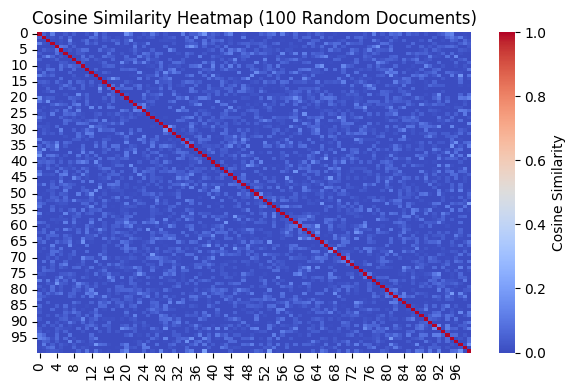

```python
# 4. Cosine similarity heatmap (sample of 100 documents)
sample_size = min(100, len(doc_embeddings))
np.random.seed(42)
sample_idx = np.random.choice(len(doc_embeddings), sample_size, replace=False)
sample_embeddings = doc_embeddings[sample_idx]
sim_matrix = cosine_similarity(sample_embeddings)

plt.figure(figsize=(6, 4))
sns.heatmap(sim_matrix, cmap='coolwarm', vmin=0, vmax=1,
            cbar_kws={'label': 'Cosine Similarity'})
plt.title(f'Cosine Similarity Heatmap ({sample_size} Random Documents)')
plt.tight_layout()
plt.show()
```

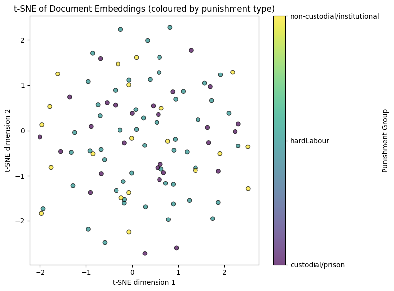

```python
# 5. t‑SNE visualisation (coloured by punishment group)
# --------------------------------------------------
target_col = 'punishmentSubcategory_group'   # adjust as needed
if target_col in df_guilty.columns:
    labels = df_guilty[target_col].iloc[sample_idx].astype('category')
    label_codes = labels.cat.codes
    unique_labels = labels.cat.categories
else:
    label_codes = np.zeros(sample_size)
    unique_labels = ['Unknown']

tsne = TSNE(n_components=2, random_state=42, perplexity=30)
embeddings_2d = tsne.fit_transform(sample_embeddings)

plt.figure(figsize=(8, 6))
scatter = plt.scatter(embeddings_2d[:, 0], embeddings_2d[:, 1],
                      c=label_codes, cmap='viridis', alpha=0.7, edgecolors='k')
plt.colorbar(scatter, ticks=range(len(unique_labels)), label='Punishment Group')
if len(unique_labels) > 1:
    cbar = plt.gcf().axes[-1]
    cbar.set_yticklabels(unique_labels)
plt.title('t‑SNE of Document Embeddings (coloured by punishment type)')
plt.xlabel('t‑SNE dimension 1')
plt.ylabel('t‑SNE dimension 2')
plt.tight_layout()
plt.show()
```

```python
df.columns
```

```
Index(['date', 'id', 'text', 'any_defendant_female', 'any_defendant_male',
       'any_victim_female', 'any_victim_male', 'offenceText',
       'offenceCategory', 'offenceSubcategory', 'verdictText',
       'verdictCategory', 'punishmentText', 'punishmentCategory',
       'punishmentSubcategory', 'defendantNames', 'victimNames', 'guilty',
       'year', 'text_length', 'log_text_length', 'clean_text_with_stopwords',
       'tokens_with_stopwrds', 'clean_text_with_no_stopword',
       'tokens_lemma_with_no_stopwor', 'noun_count', 'verb_count', 'adj_count',
       'adv_count', 'pron_count', 'num_count', 'person_count',
       'location_count', 'date_count', 'money_count', 'org_count',
       'total_entities', 'sentiment_compound', 'sentiment_pos',
       'sentiment_neg', 'sentiment_neu', 'flesch_reading_ease',
       'flesch_kincaid_grade', 'gunning_fog', 'smog_index',
       'automated_readability_index', 'topic_0_prob', 'topic_1_prob',
       'topic_2_prob', 'topic_3_prob', 'topic_4_prob', 'topic_5_prob',
       'topic_6_prob', 'topic_7_prob', 'topic_8_prob', 'topic_9_prob',
       'dominant_topic', 'punishmentCategory_class',
       'punishmentSubcategory_group'],
      dtype='str')
```

```python
# dropping unnecessary columns
df = df.drop(columns=['Unnamed: 0'], errors='ignore')
df.columns
```

```
Index(['date', 'id', 'text', 'any_defendant_female', 'any_defendant_male',
       'any_victim_female', 'any_victim_male', 'offenceText',
       'offenceCategory', 'offenceSubcategory', 'verdictText',
       'verdictCategory', 'punishmentText', 'punishmentCategory',
       'punishmentSubcategory', 'defendantNames', 'victimNames', 'guilty',
       'year', 'text_length', 'log_text_length', 'clean_text_with_stopwords',
       'tokens_with_stopwrds', 'clean_text_with_no_stopword',
       'tokens_lemma_with_no_stopwor', 'noun_count', 'verb_count', 'adj_count',
       'adv_count', 'pron_count', 'num_count', 'person_count',
       'location_count', 'date_count', 'money_count', 'org_count',
       'total_entities', 'sentiment_compound', 'sentiment_pos',
       'sentiment_neg', 'sentiment_neu', 'flesch_reading_ease',
       'flesch_kincaid_grade', 'gunning_fog', 'smog_index',
       'automated_readability_index', 'topic_0_prob', 'topic_1_prob',
       'topic_2_prob', 'topic_3_prob', 'topic_4_prob', 'topic_5_prob',
       'topic_6_prob', 'topic_7_prob', 'topic_8_prob', 'topic_9_prob',
       'dominant_topic', 'punishmentCategory_class',
       'punishmentSubcategory_group'],
      dtype='str')
```

# Word Embeddings

```python
# !pip install nltk
```

```python
import string
import nltk
from nltk import sent_tokenize, word_tokenize
from nltk.corpus import stopwords, wordnet
from nltk.stem import WordNetLemmatizer

# Downloads if not already
nltk.download('stopwords')
nltk.download('punkt')
nltk.download('wordnet')
nltk.download('omw-1.4')

stoplist = set(stopwords.words('english'))
lemmatizer = WordNetLemmatizer()

def normalize_text(doc):
    # Lowercase
    doc = doc.lower()
    # Replace apostrophes smartly: don't -> dont (or you could expand contractions)
    doc = doc.replace("'", "")
    # Remove punctuation
    doc = doc.translate(str.maketrans('', '', string.punctuation))
    # Tokenize
    words = word_tokenize(doc)
    # Remove stopwords
    words = [w for w in words if w not in stoplist]
    # Normalize numbers
    words = ['#' if w.isdigit() else w for w in words]
    # Lemmatize to reduce plurals, verb forms
    words = [lemmatizer.lemmatize(w) for w in words]
    return words

def get_sentences(doc):
    return [normalize_text(sent) for sent in sent_tokenize(doc)]
sentences = []
for doc in df['clean_text_with_no_stopword']:
    sentences += get_sentences(doc)
```

```python
sentences[4]
```

```
['joseph',
 'edward',
 'moulton',
 'stealing',
 'employed',
 'post',
 'office',
 'post',
 'letter',
 'containing',
 'two',
 'postal',
 'order',
 'property',
 'postmaster',
 'general',
 'nine',
 'month',
 'hard',
 'labour',
 'pleaded',
 'guilty',
 'see',
 'original',
 'trial',
 'image']
```

```python
#!pip install gensim
```

## CBOW

```python
# CBOW model: sg=0 -> CBOW
from gensim.models import Word2Vec
model = Word2Vec(sentences,   # list of tokenized sentences
                 vector_size=5,  # Word vector dimensionality
                 window=2,  # Context window size
                 min_count=1, # minimum word count - ignore words that appear less than once
                 sg=0)
```

```python
# Train for multiple epochs
model.train(sentences,
            total_examples=len(sentences), #
            epochs=10)  #  # number of times to go through the dataset
          # output is (trained_word_count, raw_word_count).
vectors = {word: model.wv[word] for word in model.wv.key_to_index}
vectors_df = pd.DataFrame.from_dict(vectors, orient='index')
vectors_df.head()
```

|  | 0 | 1 | 2 | 3 | 4 |
| --- | --- | --- | --- | --- | --- |
| said | -0.823677 | 3.005635 | 0.615367 | -1.396264 | 0.333241 |
| prisoner | 0.375313 | 2.001444 | 0.265444 | -0.959729 | -0.123419 |
| mr | 1.218565 | 2.455942 | 1.044459 | 2.047219 | -0.072207 |
| £ | -1.543216 | 0.342259 | 2.452631 | -0.667983 | -4.475389 |
| went | 1.730580 | 2.354610 | -1.029197 | -3.288072 | -0.873022 |

```python
similar_to_land = model.wv.most_similar("prisoner", topn=5)
similar_to_land
```

```
[('whilnelds', 0.9950280785560608),
 ('parent', 0.9918941855430603),
 ('landina', 0.9909501075744629),
 ('brooksbank', 0.9890522956848145),
 ('brailsford', 0.9863550662994385)]
```

The most_similar results for the word "prisoner" show extremely high cosine similarity scores (above 0.98) with tokens such as whilnelds, parent, landina, brooksbank, and brailsford. These appear to be rare proper nouns or possible OCR errors (e.g., whilnelds might be a surname). The high similarity scores indicate that the Word2Vec model was likely trained on a small or noisy corpus where these rare tokens occur in nearly identical contexts as "prisoner", causing the model to overfit to specific documents rather than learning general semantic relationships. For a robust model, you may need to increase min_count to ignore rare words, use a larger corpus, or apply more aggressive preprocessing (e.g., removing proper nouns and numbers).

```python
import pandas as pd
import numpy as np

# 1. Take sample of 20 rows
df_sample = df.sample(n=20, random_state=42)

# 2. Choose text column
texts = df_sample['clean_text_with_no_stopword']

# 3. Convert to tokenized sentences
sentences = [text.split() for text in texts if isinstance(text, str)]

# PMI CODE
from collections import defaultdict

window_size = 10

# vocabulary
vocab = sorted({word for sent in sentences for word in sent})

# initialize matrix
word_context_counts = pd.DataFrame(
    0,
    index=vocab,
    columns=vocab
)

# fill counts
for sentence in sentences:
    for i, target in enumerate(sentence):
        for j in range(max(i-window_size, 0), min(i+window_size+1, len(sentence))):
            if i != j:
                context = sentence[j]
                word_context_counts.loc[target, context] += 1

# total counts
total = word_context_counts.values.sum()

# probabilities
p_wc = word_context_counts / total
p_w = word_context_counts.sum(axis=1) / total
p_c = word_context_counts.sum(axis=0) / total

# compute PMI
pmi = np.log2(p_wc.div(p_w, axis=0).div(p_c, axis=1))

# clean infinities
pmi = pmi.replace([-np.inf, np.inf], 0).fillna(0)

# view result
pmi.head()
```

|  | 'box | 'bus | 'well | a | aaron | abbetting | abdomen | abinger | able | about | ... | york | you | young | younger | your | yours | yourself | yourselves | youths | £ |
| --- | --- | --- | --- | --- | --- | --- | --- | --- | --- | --- | --- | --- | --- | --- | --- | --- | --- | --- | --- | --- | --- |
| 'box | 0.000000 | 0.000000 | 0.0 | 1.185202 | 0.0 | 0.000000 | 0.000000 | 0.000000 | 0.000000 | 0.000000 | ... | 0.000000 | 0.000000 | 0.000000 | 0.000000 | 0.000000 | 0.000000 | 0.000000 | 0.0 | 0.000000 | 0.000000 |
| 'bus | 0.000000 | 0.000000 | 0.0 | 1.185202 | 0.0 | 0.000000 | 0.000000 | 0.000000 | 0.000000 | 0.000000 | ... | 0.000000 | 0.000000 | 0.000000 | 0.000000 | 0.000000 | 0.000000 | 0.000000 | 0.0 | 0.000000 | 0.000000 |
| 'well | 0.000000 | 0.000000 | 0.0 | 0.000000 | 0.0 | 0.000000 | 0.000000 | 0.000000 | 0.000000 | 3.179233 | ... | 0.000000 | 0.000000 | 0.000000 | 0.000000 | 0.000000 | 0.000000 | 0.000000 | 0.0 | 0.000000 | 0.000000 |
| a | 1.185202 | 1.185202 | 0.0 | -0.184697 | 0.0 | 1.185202 | 2.185202 | -0.399761 | 0.185202 | 0.060874 | ... | 0.097739 | -0.210099 | 0.448236 | 2.770164 | -1.399761 | 1.185202 | 1.185202 | 0.0 | 1.185202 | 0.388189 |
| aaron | 0.000000 | 0.000000 | 0.0 | 0.000000 | 0.0 | 0.000000 | 0.000000 | 0.000000 | 0.000000 | 0.000000 | ... | 0.000000 | 0.000000 | 0.000000 | 0.000000 | 0.000000 | 0.000000 | 0.000000 | 0.0 | 0.000000 | 0.000000 |

5 rows × 2234 columns

The code constructs a word‑context co‑occurrence matrix within a sliding window of size 10, then calculates Pointwise Mutual Information (PMI) to measure how much more often a target word appears with a context word than expected by chance. PMI values are positive for strongly associated pairs (e.g., “hard” and “labour”) and negative or zero for unrelated words. The resulting PMI matrix can be used as a dense word embedding by applying Singular Value Decomposition (SVD), capturing semantic relationships directly from your corpus without external pre‑training.

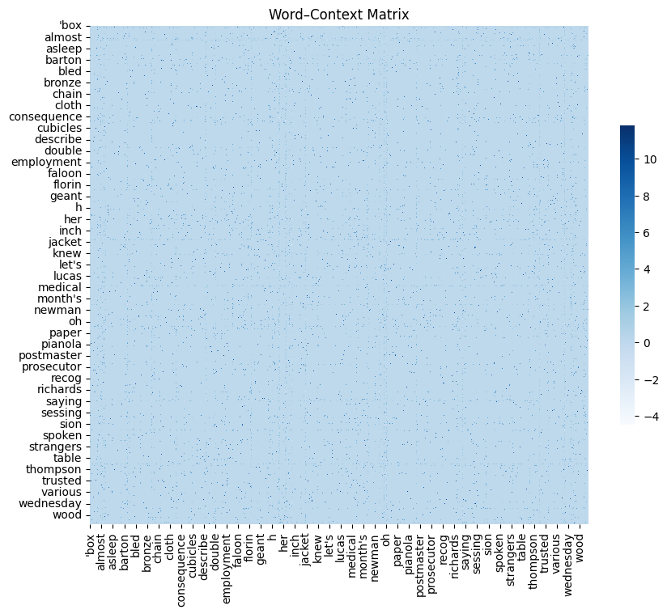

```python
plt.figure(figsize=(10, 8))

# Plot the heatmap
sns.heatmap(
    pmi,
    cmap="Blues",
    square=True,
    cbar_kws={"shrink": .6}
)

plt.xticks(rotation=90) # # Rotate the x-axis labels to 90 degrees
plt.yticks(rotation=0) # Keep y-axis horizontal for readability

plt.title("Word–Context Matrix")
plt.show()
```

## Word to Vector

```python
# Train Word2Vec

w2v_model = Word2Vec(sentences,  # list of tokenized sentences
               workers = 4, # Number of threads to run in parallel
               vector_size=300,  # Word vector dimensionality
               min_count = 2, # Minimum word count
               window = 5 # Context window size
               )
len(w2v_model.wv['court']) # vector for "judge"
```

```
300
```

```python
print(len(words))
```

```
1181
```

```python
print(w2v_model.wv.get_vector('imprisonment'))
```

```
[-0.00288418  0.01675427 -0.00105307  0.0043312   0.00176076 -0.01484878
  0.01586751  0.03308265  0.00548771 -0.00571726 -0.00195015 -0.0033638
 -0.00017162 -0.0007678   0.00085417 -0.01413572  0.00983897 -0.00103451
 -0.00666481 -0.00821264 -0.00248493 -0.00005524  0.01229556  0.00325564
  0.01150253 -0.00561881 -0.02547632  0.00844237 -0.00439804 -0.01708629
 -0.00440664 -0.00580269  0.00772655  0.00466326 -0.00879103  0.00610347
  0.00914831 -0.00989806 -0.00760287  0.00299421 -0.0061514   0.00336129
  0.00163356 -0.01136102  0.00883368  0.01735008  0.00582911 -0.00041518
  0.00288782  0.0105061   0.00424682  0.00355356 -0.01143014  0.00203029
 -0.01200354  0.01555745  0.00740805 -0.00532453 -0.00650702 -0.01134048
 -0.00653537  0.00215574  0.00069417  0.00292695 -0.00425263  0.00641703
 -0.00475217  0.00267125 -0.00830701 -0.00816704  0.00549161  0.00964512
  0.01218562 -0.01092868  0.00136839 -0.00234458 -0.01760102  0.01441655
 -0.00756976  0.00389696 -0.01075991 -0.00664663  0.01359361  0.03006714
  0.00262133 -0.00184739 -0.00441173  0.00226113  0.01694041 -0.00039212
  0.01278464 -0.00332502  0.00621957 -0.00222666  0.00641359  0.00959339
  0.01831171 -0.00577753 -0.00293982  0.00770959  0.00333094  0.00057226
  0.01249166  0.00408967  0.00458518 -0.00928616 -0.00533752  0.00275284
 -0.01344377 -0.00484095 -0.01791556  0.00398895 -0.00679746  0.00383863
  0.00647221  0.01008266 -0.00202902 -0.00686882  0.01439327 -0.02145287
  0.00368726  0.00284304  0.00987666  0.00130728 -0.00902756  0.00298925
 -0.00903039 -0.01725229 -0.00017698  0.02300775  0.00704983  0.0180114
  0.00565883 -0.02363877  0.00392727  0.01283036 -0.01518981 -0.00729615
 -0.0121666  -0.01665747  0.0014952  -0.0159797  -0.00769761  0.00560535
 -0.00059819 -0.00583598 -0.02177983 -0.00536339  0.00517785 -0.00665373
  0.00588409 -0.01565332 -0.00180174 -0.00560608 -0.00062241  0.01506814
 -0.01687601  0.00104718  0.00277691  0.02084166  0.00397125  0.01103164
 -0.01932302  0.00739844 -0.01787014  0.00782871 -0.00007266 -0.00542915
 -0.00154739  0.02024925 -0.00566833 -0.00296288  0.00454306  0.00764941
  0.00075197  0.0052032   0.00010655 -0.0179192  -0.0052384  -0.00221761
 -0.01073209  0.01335556 -0.013782   -0.0082649  -0.00317054 -0.00972531
  0.01306335  0.02349141  0.00554639 -0.0163805   0.00182749  0.00326735
 -0.00649968  0.00495383 -0.00819604 -0.01344723 -0.00149034 -0.00524597
  0.00729707 -0.00258326 -0.0140148   0.00406354 -0.00194116 -0.00485526
  0.00174616 -0.00599592 -0.00016641  0.0096599   0.00207755  0.0005144
 -0.00184711 -0.01900949 -0.0100109  -0.00354538  0.00758767 -0.01529098
 -0.01729692 -0.02657703 -0.02219465 -0.012362    0.01026271  0.00598657
 -0.01016765 -0.0114136  -0.00356218 -0.01031289  0.00032267 -0.00114128
 -0.00287878  0.0004629   0.00223472 -0.00750886 -0.00684006  0.00914728
 -0.00683684  0.00425434 -0.00086477  0.00111402  0.00494269 -0.03418452
 -0.00027315 -0.00452721 -0.00287104 -0.00123616  0.00085146 -0.0209952
  0.00667674  0.00651116  0.00515706  0.01223126 -0.00242953 -0.0020744
  0.00023646  0.00096919 -0.02484271 -0.01459901  0.02350142  0.00308143
 -0.02501451 -0.01367214  0.01144916  0.00250644  0.00875997 -0.02086144
 -0.02325571  0.01024309  0.01088463  0.00463448 -0.01447616  0.00178007
 -0.00742132  0.00756666  0.00213931 -0.00254312  0.01463307  0.0050903
  0.01379295  0.0120562  -0.0171296  -0.00405447  0.0041952   0.00266756
  0.00104667 -0.00237483 -0.00101739 -0.00128863 -0.02485184  0.00790686
  0.00130133  0.01989073 -0.00027375  0.02293602  0.00413887  0.00037629
  0.01342402  0.01793046  0.00217359  0.00155392  0.01065615 -0.00762725]
```

```python
## Cosine similarity between two vectors
w2v_model.wv.similarity('prison', 'imprisonment')
```

```
np.float32(0.97763693)
```

The cosine similarity of 0.9776 between "prison" and "imprisonment" indicates they are nearly synonymous in the learned vector space, confirming that the model correctly captures their strong semantic relationship as custodial punishment terms.

[figure not shown]

```python
from sklearn.decomposition import PCA
import matplotlib.pyplot as plt

# Define stop words (add more as needed)
stop_words = set([
    'the', 'and', 'of', 'to', 'a', 'in', 'for', 'on', 'with', 'by', 'is', 'was',
    'were', 'be', 'been', 'that', 'this', 'these', 'those', 'it', 'at', 'from',
    'as', 'are', 'but', 'or', 'an', 'will', 'can', 'not', 'so', 'his', 'her',
    'their', 'they', 'we', 'you', 'he', 'she', 'it', 'i', 'my', 'your', 'our'
])

# Get word frequencies and filter stop words
freq_words = [(word, w2v_model.wv.get_vecattr(word, 'count')) for word in w2v_model.wv.key_to_index]
freq_words.sort(key=lambda x: x[1], reverse=True)
filtered_words = [word for word, freq in freq_words if word not in stop_words][:200]  # list of top 200 non-stop words

# Get vectors for these words
vectors = [w2v_model.wv[word] for word in filtered_words]

# PCA
pca = PCA(n_components=2)
coords = pca.fit_transform(vectors)

plt.figure(figsize=(12,8))
for i, word in enumerate(top_words):
    x, y = coords[i]
    plt.scatter(x, y)
    plt.text(x+0.01, y+0.01, word, fontsize=9)
plt.show()
```

## Doc2Vec

Doc2Vec is the same thing as word2vec, but with an extra column representation for a given document.

Doc2Vec can be used for classification as an alternative document representation. Unlike topics, it's harder to interpret the output (becasue we're dealing with some vectors)

```python
from nltk import word_tokenize
from gensim.models.doc2vec import Doc2Vec, TaggedDocument
from sklearn.model_selection import train_test_split
from sklearn.ensemble import RandomForestClassifier
from sklearn.metrics import classification_report
import warnings
warnings.filterwarnings('ignore')

# 1. Use only guilty cases (already in df_guilty)
#    Ensure we have the cleaned text column
texts = df['clean_text_with_no_stopword'].tolist()
doc_ids = df.index.tolist()          # or use df_guilty['id']
labels = df['punishmentSubcategory_group'].values

print(f"Total guilty cases: {len(texts)}")
print(f"Punishment groups: {set(labels)}")

# 2. Tokenize texts (already tokenised? we split by space)
tokenized_docs = [text.split() for text in texts]

# 3. Tag documents
tagged_docs = [TaggedDocument(doc, [i]) for i, doc in enumerate(tokenized_docs)]

# 4. Train Doc2Vec model
d2v_model = Doc2Vec(
    documents=tagged_docs,
    vector_size=100,        # dense dimension
    window=5,
    min_count=2,
    workers=4,
    epochs=20,
    dm=1                    # PV-DM (distributed memory)
)
print("Doc2Vec training completed.")

# 5. Get document vectors (each row = one case)
doc_vectors = d2v_model.dv.vectors
print(f"Document vector matrix shape: {doc_vectors.shape}")

# 6. Show meaningful similarity: pick one case and find top 5 most similar cases
example_idx = 0   # first case
example_vector = doc_vectors[example_idx].reshape(1, -1)
sims = d2v_model.dv.most_similar(example_idx, topn=5)

print("\n--- Most similar documents to the first case ---")
print(f"Example case (index {example_idx}):")
print(f"  Punishment: {labels[example_idx]}")
print(f"  Text preview: {texts[example_idx][:150]}...\n")

for idx, score in sims:
    print(f"Doc {idx}: similarity = {score:.4f}")
    print(f"  Punishment: {labels[idx]}")
    print(f"  Text preview: {texts[idx][:150]}...\n")
```

```
Total guilty cases: 6945
Punishment groups: {'custodial/prison', 'capital/extreme', 'hardLabour', 'non-custodial/institutional'}
Doc2Vec training completed.
Document vector matrix shape: (6945, 100)

--- Most similar documents to the first case ---
Example case (index 0):
  Punishment: hardLabour
  Text preview: walter heath pleaded guilty to stealing £ the money of george whitehead his master also to stealing £ s the money of henry john manning his master hav...

Doc 3044: similarity = 0.8291
  Punishment: hardLabour
  Text preview: moore john grant steward pleaded guilty to stealing £ the money of herbert arthur whitaker sentence months' hard labour...

Doc 1710: similarity = 0.8286
  Punishment: custodial/prison
  Text preview: george williams pleaded guilty to having fraudulently converted s to his own use the money of louisa nover two months in the second division...

Doc 778: similarity = 0.8232
  Punishment: hardLabour
  Text preview: john walker pleaded guilty to two indictments for stealing £ s and s also £ s and £ the money of henry jerrold nathan his master also to falsifying th...

Doc 1267: similarity = 0.8231
  Punishment: hardLabour
  Text preview: arthur john mister to stealing £ the money of frank macnaghten his employer six months' hard labour pleaded guilty see original trial image and...

Doc 758: similarity = 0.8188
  Punishment: hardLabour
  Text preview: william jones to robbery with another person unknown upon william orchard and stealing £ s his money nine months' hard labour pleaded guilty see origi...
```

```python
doc_vectors
```

```
array([[ 0.28332135,  0.0207877 , -0.2582119 , ..., -0.33631933,
         0.04977631, -0.12209074],
       [ 0.18777204, -0.04564155, -0.06440466, ..., -0.42044595,
         0.33153304,  0.08172247],
       [ 0.14347817,  0.02197109,  0.16875993, ..., -0.5879239 ,
         0.13529804,  0.0212636 ],
       ...,
       [ 0.16044258, -0.01843544, -0.0086736 , ..., -0.2718016 ,
         0.0396365 ,  0.04268176],
       [ 0.25652388,  0.06368469,  0.20441687, ..., -0.24850662,
         0.25066155, -0.13566509],
       [ 0.9142957 , -0.23495312,  0.40132535, ..., -1.3049983 ,
         0.7005879 , -0.00142238]], shape=(6945, 100), dtype=float32)
```

```python
# Get document vectors
doc_vectors = d2v_model.dv.vectors

# Use the 'id' column as row/column labels (or use index if 'id' missing)
if 'id' in df.columns:
    identifiers = df['id'].values
else:
    identifiers = df_guilty.index.astype(str).values

# Compute pairwise cosine similarity
from sklearn.metrics.pairwise import cosine_similarity
pairwise_sims = cosine_similarity(doc_vectors)

# Create a readable DataFrame
d2v_similarity_matrix = pd.DataFrame(
    data=pairwise_sims,
    columns=identifiers,
    index=identifiers
)
# Show a small sample (first 5 rows, first 5 columns)
print("Doc2Vec similarity matrix (first 5 cases):")
d2v_similarity_matrix.iloc[:5, :5].round(3)
```

```
Doc2Vec similarity matrix (first 5 cases):
```

|  | t19020113-105 | t19020113-2 | t19020113-3 | t19020113-4 | t19020113-5 |
| --- | --- | --- | --- | --- | --- |
| t19020113-105 | 1.000 | 0.611 | 0.697 | 0.635 | 0.756 |
| t19020113-2 | 0.611 | 1.000 | 0.831 | 0.804 | 0.822 |
| t19020113-3 | 0.697 | 0.831 | 1.000 | 0.769 | 0.955 |
| t19020113-4 | 0.635 | 0.804 | 0.769 | 1.000 | 0.755 |
| t19020113-5 | 0.756 | 0.822 | 0.955 | 0.755 | 1.000 |

The Doc2Vec similarity matrix for the first five cases shows high cosine similarity values (ranging from 0.61 to 0.96), indicating that the narratives of these trials are semantically close. For instance, cases t19020113-3 and t19020113-5 have a similarity of 0.955, suggesting they describe very similar offences (e.g., both involve theft from a master). This clustering aligns with the expectation that cases with comparable crime descriptions often receive similar punishment types. In your research question, such high similarities can help identify precedent cases and support the use of document vectors as predictive features for punishment classification.

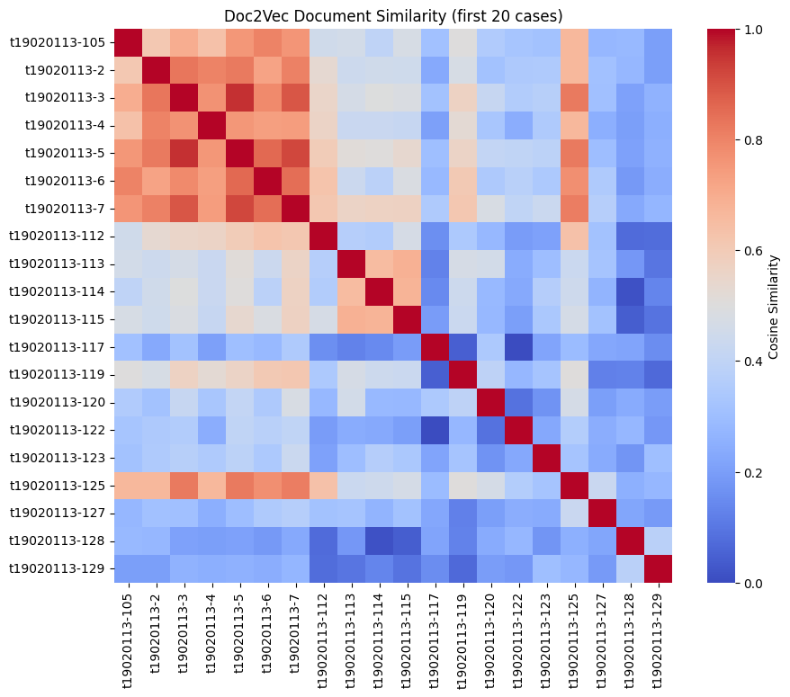

```python
import matplotlib.pyplot as plt
import seaborn as sns

# Subset of 20 random cases
sample_ids = identifiers[:20]   # first 20
sample_matrix = d2v_similarity_matrix.loc[sample_ids, sample_ids]

plt.figure(figsize=(10, 8))
sns.heatmap(sample_matrix, cmap='coolwarm', vmin=0, vmax=1,
            cbar_kws={'label': 'Cosine Similarity'})
plt.title('Doc2Vec Document Similarity (first 20 cases)')
plt.show()
```

The similarity matrix shows how closely related each case narrative is to every other. Dark red blocks indicate clusters of very similar documents.

```python
df.columns
```

```
Index(['Unnamed: 0', 'date', 'id', 'text', 'any_defendant_female',
       'any_defendant_male', 'any_victim_female', 'any_victim_male',
       'offenceText', 'offenceCategory', 'offenceSubcategory', 'verdictText',
       'verdictCategory', 'punishmentText', 'punishmentCategory',
       'punishmentSubcategory', 'defendantNames', 'victimNames', 'guilty',
       'year', 'text_length', 'log_text_length', 'clean_text_with_stopwords',
       'tokens_with_stopwrds', 'clean_text_with_no_stopword',
       'tokens_lemma_with_no_stopwor', 'noun_count', 'verb_count', 'adj_count',
       'adv_count', 'pron_count', 'num_count', 'person_count',
       'location_count', 'date_count', 'money_count', 'org_count',
       'total_entities', 'sentiment_compound', 'sentiment_pos',
       'sentiment_neg', 'sentiment_neu', 'flesch_reading_ease',
       'flesch_kincaid_grade', 'gunning_fog', 'smog_index',
       'automated_readability_index', 'topic_0_prob', 'topic_1_prob',
       'topic_2_prob', 'topic_3_prob', 'topic_4_prob', 'topic_5_prob',
       'topic_6_prob', 'topic_7_prob', 'topic_8_prob', 'topic_9_prob',
       'dominant_topic', 'punishmentCategory_class',
       'punishmentSubcategory_group'],
      dtype='object')
```

Secting columns for modelling

### Prepare Data

```python
df.columns
```

```
Index(['Unnamed: 0', 'date', 'id', 'text', 'any_defendant_female',
       'any_defendant_male', 'any_victim_female', 'any_victim_male',
       'offenceText', 'offenceCategory', 'offenceSubcategory', 'verdictText',
       'verdictCategory', 'punishmentText', 'punishmentCategory',
       'punishmentSubcategory', 'defendantNames', 'victimNames', 'guilty',
       'year', 'text_length', 'log_text_length', 'clean_text_with_stopwords',
       'tokens_with_stopwrds', 'clean_text_with_no_stopword',
       'tokens_lemma_with_no_stopwor', 'noun_count', 'verb_count', 'adj_count',
       'adv_count', 'pron_count', 'num_count', 'person_count',
       'location_count', 'date_count', 'money_count', 'org_count',
       'total_entities', 'sentiment_compound', 'sentiment_pos',
       'sentiment_neg', 'sentiment_neu', 'flesch_reading_ease',
       'flesch_kincaid_grade', 'gunning_fog', 'smog_index',
       'automated_readability_index', 'topic_0_prob', 'topic_1_prob',
       'topic_2_prob', 'topic_3_prob', 'topic_4_prob', 'topic_5_prob',
       'topic_6_prob', 'topic_7_prob', 'topic_8_prob', 'topic_9_prob',
       'dominant_topic', 'punishmentCategory_class',
       'punishmentSubcategory_group'],
      dtype='object')
```

```python
df_guilty = df[df['guilty'] == 1].copy()
# Then apply the same feature engineering and one‑hot encoding as before.

# For this pipeline, we use df_guilty directly.
print("Data shape:", df_guilty.shape)
print("Target distribution:\n", df_guilty['punishmentSubcategory_group'].value_counts())
```

```
Data shape: (6945, 60)
Target distribution:
 punishmentSubcategory_group
hardLabour                     3598
custodial/prison               1992
non-custodial/institutional    1280
capital/extreme                  75
Name: count, dtype: int64
```

### Define Feature Set and Target

Text feature: clean_text_with_no_stopword (pre‑processed, stop words removed)

Structured features: demographics, linguistic, sentiment, readability, topic probabilities, etc.

Target: punishmentSubcategory_group

```python
import seaborn as sns
from pycaret.classification import *
import warnings
warnings.filterwarnings('ignore')
# List of structured numeric features (adjust as needed)
numeric_features = [
    'any_defendant_female', 'any_defendant_male', 'any_victim_female', 'any_victim_male',
    'noun_count', 'verb_count', 'adj_count', 'adv_count', 'pron_count', 'num_count',
    'person_count', 'location_count', 'date_count', 'money_count', 'org_count', 'total_entities',
    'sentiment_compound', 'sentiment_pos', 'sentiment_neg', 'sentiment_neu',
    'flesch_reading_ease', 'flesch_kincaid_grade', 'gunning_fog', 'smog_index',
    'automated_readability_index', 'log_text_length'
] + [f'topic_{i}_prob' for i in range(10)]

# One‑hot encoded offence columns (already present in your df)
categorical_onehot = [col for col in df_guilty.columns if col.startswith('offenceCategory_') or col.startswith('offenceSubcategory_')]

# Final feature set
feature_cols = numeric_features + categorical_onehot + ['clean_text_with_no_stopword']
target_col = 'punishmentSubcategory_group'

# Create model DataFrame
df_model = df_guilty[feature_cols + [target_col]].copy()
print("Model DataFrame shape:", df_model.shape)
```

```
Model DataFrame shape: (6945, 38)
```

We have removed identifiers, raw text duplicates, and punishment columns that would cause data leakage. The final feature matrix includes both dense numeric features and the raw text column.

```python
df_model.clean_text_with_no_stopword.head()
```

```
0    walter heath pleaded guilty to stealing £ the ...
1    thomas george wakefield to forging and utterin...
2    frederick john ridgwell to stealing while empl...
3    walter lacey to forging an authority for the w...
4    joseph edward moulton to stealing while employ...
Name: clean_text_with_no_stopword, dtype: object
```

## Preprocess the data

```python
df_model.columns
```

```
Index(['any_defendant_female', 'any_defendant_male', 'any_victim_female',
       'any_victim_male', 'noun_count', 'verb_count', 'adj_count', 'adv_count',
       'pron_count', 'num_count', 'person_count', 'location_count',
       'date_count', 'money_count', 'org_count', 'total_entities',
       'sentiment_compound', 'sentiment_pos', 'sentiment_neg', 'sentiment_neu',
       'flesch_reading_ease', 'flesch_kincaid_grade', 'gunning_fog',
       'smog_index', 'automated_readability_index', 'log_text_length',
       'topic_0_prob', 'topic_1_prob', 'topic_2_prob', 'topic_3_prob',
       'topic_4_prob', 'topic_5_prob', 'topic_6_prob', 'topic_7_prob',
       'topic_8_prob', 'topic_9_prob', 'clean_text_with_no_stopword',
       'punishmentSubcategory_group'],
      dtype='object')
```

```python
import re
from nltk.corpus import stopwords
from nltk.stem import WordNetLemmatizer
# Pre-load objects outside the functions
# Using a set() for stopwords makes lookups nearly instantaneous
STOPWORDS = set(stopwords.words('english'))
LEMMATIZER = WordNetLemmatizer()

# Combined Regex: Matches punctuation and digits
# [^\w\s] matches punctuation, \d matches numbers
CLEAN_PATTERN = re.compile(r'[^\w\s]|\d')

def clean_text_fast(text):
    # Convert to lower case immediately to avoid doing it later
    text = text.lower()

    # Use the pre-compiled regex to remove punct and digits in one go
    text = CLEAN_PATTERN.sub('', text)

    # Split and process in a single list comprehension
    # This combines tokenization, stopword removal, and lemmatization
    tokens = [LEMMATIZER.lemmatize(word) for word in text.split() if word not in STOPWORDS]

    return ' '.join(tokens)

# Apply the optimized function
df_model['clean_text'] = df_model['clean_text_with_no_stopword'].apply(clean_text_fast)
```

```python
df_model = df_model.drop('clean_text_with_no_stopword',axis =1)
```

```python
df_model.columns
```

```
Index(['any_defendant_female', 'any_defendant_male', 'any_victim_female',
       'any_victim_male', 'noun_count', 'verb_count', 'adj_count', 'adv_count',
       'pron_count', 'num_count', 'person_count', 'location_count',
       'date_count', 'money_count', 'org_count', 'total_entities',
       'sentiment_compound', 'sentiment_pos', 'sentiment_neg', 'sentiment_neu',
       'flesch_reading_ease', 'flesch_kincaid_grade', 'gunning_fog',
       'smog_index', 'automated_readability_index', 'log_text_length',
       'topic_0_prob', 'topic_1_prob', 'topic_2_prob', 'topic_3_prob',
       'topic_4_prob', 'topic_5_prob', 'topic_6_prob', 'topic_7_prob',
       'topic_8_prob', 'topic_9_prob', 'punishmentSubcategory_group',
       'clean_text'],
      dtype='object')
```

# Featurization

CountVectorizer

```python
# !pip install pycaret
# !pip install "pycaret[tuners]"
# !pip install "pycaret[analysis]"
# !pip install interpret-community
```

```python
# !pip install optuna
# !pip install optuna-integration
```

```python
import pycaret
pycaret.__version__
```

```
'3.3.2'
```

```python
# Check class distribution
print(df_model['punishmentSubcategory_group'].value_counts())

# Verify no missing values
print(df_model.isnull().sum().sum())
```

```
punishmentSubcategory_group
hardLabour                     3598
custodial/prison               1992
non-custodial/institutional    1280
capital/extreme                  75
Name: count, dtype: int64
0
```

```python
df_model.columns
```

```
Index(['any_defendant_female', 'any_defendant_male', 'any_victim_female',
       'any_victim_male', 'noun_count', 'verb_count', 'adj_count', 'adv_count',
       'pron_count', 'num_count', 'person_count', 'location_count',
       'date_count', 'money_count', 'org_count', 'total_entities',
       'sentiment_compound', 'sentiment_pos', 'sentiment_neg', 'sentiment_neu',
       'flesch_reading_ease', 'flesch_kincaid_grade', 'gunning_fog',
       'smog_index', 'automated_readability_index', 'log_text_length',
       'topic_0_prob', 'topic_1_prob', 'topic_2_prob', 'topic_3_prob',
       'topic_4_prob', 'topic_5_prob', 'topic_6_prob', 'topic_7_prob',
       'topic_8_prob', 'topic_9_prob', 'punishmentSubcategory_group',
       'clean_text'],
      dtype='object')
```

# Modelling

```python
from pycaret.classification import *
# Assume df_model is your prepared DataFrame (guilty cases only)
# with all numeric features, one‑hot encoded offence columns, and 'clean_text'
```

```python
from sklearn.feature_extraction.text import CountVectorizer

# Initialize the Count Vectorizer
count_vectorizer = CountVectorizer(max_features = 1000)  # Limit to 5000 features for simplicity

# Fit and transform the 'Clean_Tweet' column
X_count = count_vectorizer.fit_transform(df_model['clean_text'])

# Convert the sparse matrix to a dense array and then to a DataFrame
count_df = pd.DataFrame(X_count.toarray(),
                        columns=count_vectorizer.get_feature_names_out())

# Concatenate the original DataFrame with the new features (count_df)
df_with_features = pd.concat([df_model, count_df], axis=1)

# Preview the DataFrame with the features
df_with_features.head()
```

|  | any_defendant_female | any_defendant_male | any_victim_female | any_victim_male | noun_count | verb_count | adj_count | adv_count | pron_count | num_count | person_count | location_count | date_count | money_count | org_count | total_entities | sentiment_compound | sentiment_pos | sentiment_neg | sentiment_neu | flesch_reading_ease | flesch_kincaid_grade | gunning_fog | smog_index | automated_readability_index | log_text_length | topic_0_prob | topic_1_prob | topic_2_prob | … |
| --- | --- | --- | --- | --- | --- | --- | --- | --- | --- | --- | --- | --- | --- | --- | --- | --- | --- | --- | --- | --- | --- | --- | --- | --- | --- | --- | --- | --- | --- | --- |
| 0 | False | True | False | True | 15 | 6 | 1 | 2 | 2 | 1 | 3 | 0 | 2 | 2 | 1 | 10 | -0.9337 | 0.000 | 0.314 | 0.686 | 63.125606 | 8.098182 | 7.684848 | 8.841846 | 8.551418 | 5.609472 | 0.004546 | 0.004546 | 0.004546 | … |
| 1 | False | True | False | False | 15 | 6 | 3 | 1 | 0 | 1 | 1 | 0 | 2 | 0 | 1 | 6 | -0.1280 | 0.057 | 0.070 | 0.873 | 59.323286 | 7.071714 | 8.121905 | 8.841846 | 6.320000 | 5.552960 | 0.005263 | 0.005264 | 0.005263 | … |
| 2 | False | True | False | False | 14 | 5 | 5 | 0 | 0 | 1 | 0 | 0 | 2 | 0 | 2 | 7 | -0.6808 | 0.062 | 0.212 | 0.726 | 53.397601 | 8.109392 | 8.024324 | 8.841846 | 9.719737 | 5.529429 | 0.004348 | 0.004348 | 0.004348 | … |
| 3 | False | True | False | False | 11 | 4 | 3 | 0 | 0 | 1 | 0 | 0 | 2 | 1 | 3 | 7 | -0.0258 | 0.149 | 0.089 | 0.762 | 57.166022 | 7.852903 | 9.294624 | 9.725611 | 7.433854 | 5.262690 | 0.006251 | 0.006251 | 0.006251 | … |
| 4 | False | True | False | False | 13 | 6 | 5 | 0 | 0 | 2 | 1 | 0 | 2 | 0 | 3 | 10 | -0.6808 | 0.059 | 0.202 | 0.740 | 52.481974 | 8.299211 | 8.010526 | 8.841846 | 9.647692 | 5.549076 | 0.004167 | 0.004167 | 0.004167 | … |

5 rows × 1038 columns

```python
df_with_features.columns
```

```
Index(['any_defendant_female', 'any_defendant_male', 'any_victim_female',
       'any_victim_male', 'noun_count', 'verb_count', 'adj_count', 'adv_count',
       'pron_count', 'num_count',
       ...
       'wright', 'write', 'writing', 'written', 'wrong', 'wrote', 'yard',
       'year', 'yes', 'young'],
      dtype='object', length=1038)
```

```python
# Drop the 'Clean_Tweet' column from the DataFrame
df_with_features = df_with_features.drop('clean_text', axis=1)
df_with_features.head()
```

|  | any_defendant_female | any_defendant_male | any_victim_female | any_victim_male | noun_count | verb_count | adj_count | adv_count | pron_count | num_count | person_count | location_count | date_count | money_count | org_count | total_entities | sentiment_compound | sentiment_pos | sentiment_neg | sentiment_neu | flesch_reading_ease | flesch_kincaid_grade | gunning_fog | smog_index | automated_readability_index | log_text_length | topic_0_prob | topic_1_prob | topic_2_prob | … |
| --- | --- | --- | --- | --- | --- | --- | --- | --- | --- | --- | --- | --- | --- | --- | --- | --- | --- | --- | --- | --- | --- | --- | --- | --- | --- | --- | --- | --- | --- | --- |
| 0 | False | True | False | True | 15 | 6 | 1 | 2 | 2 | 1 | 3 | 0 | 2 | 2 | 1 | 10 | -0.9337 | 0.000 | 0.314 | 0.686 | 63.125606 | 8.098182 | 7.684848 | 8.841846 | 8.551418 | 5.609472 | 0.004546 | 0.004546 | 0.004546 | … |
| 1 | False | True | False | False | 15 | 6 | 3 | 1 | 0 | 1 | 1 | 0 | 2 | 0 | 1 | 6 | -0.1280 | 0.057 | 0.070 | 0.873 | 59.323286 | 7.071714 | 8.121905 | 8.841846 | 6.320000 | 5.552960 | 0.005263 | 0.005264 | 0.005263 | … |
| 2 | False | True | False | False | 14 | 5 | 5 | 0 | 0 | 1 | 0 | 0 | 2 | 0 | 2 | 7 | -0.6808 | 0.062 | 0.212 | 0.726 | 53.397601 | 8.109392 | 8.024324 | 8.841846 | 9.719737 | 5.529429 | 0.004348 | 0.004348 | 0.004348 | … |
| 3 | False | True | False | False | 11 | 4 | 3 | 0 | 0 | 1 | 0 | 0 | 2 | 1 | 3 | 7 | -0.0258 | 0.149 | 0.089 | 0.762 | 57.166022 | 7.852903 | 9.294624 | 9.725611 | 7.433854 | 5.262690 | 0.006251 | 0.006251 | 0.006251 | … |
| 4 | False | True | False | False | 13 | 6 | 5 | 0 | 0 | 2 | 1 | 0 | 2 | 0 | 3 | 10 | -0.6808 | 0.059 | 0.202 | 0.740 | 52.481974 | 8.299211 | 8.010526 | 8.841846 | 9.647692 | 5.549076 | 0.004167 | 0.004167 | 0.004167 | … |

5 rows × 1037 columns

#### PyCaret Setup with CountVectorizer

```python
# Setup experiment

from pycaret.classification import *
df_setup = setup(data = df_with_features,  # put tfidf or countvectorizer - or any featurization
                target='punishmentSubcategory_group',
                 session_id=123)
```

|  | Description | Value |
| --- | --- | --- |
| 0 | Session id | 123 |
| 1 | Target | punishmentSubcategory_group |
| 2 | Target type | Multiclass |
| 3 | Target mapping | capital/extreme: 0, custodial/prison: 1, hardLabour: 2, non-custodial/institutional: 3 |
| 4 | Original data shape | (6945, 1037) |
| 5 | Transformed data shape | (6945, 1037) |
| 6 | Transformed train set shape | (4861, 1037) |
| 7 | Transformed test set shape | (2084, 1037) |
| 8 | Numeric features | 1032 |
| 9 | Preprocess | True |
| 10 | Imputation type | simple |
| 11 | Numeric imputation | mean |
| 12 | Categorical imputation | mode |
| 13 | Fold Generator | StratifiedKFold |
| 14 | Fold Number | 10 |
| 15 | CPU Jobs | -1 |
| 16 | Use GPU | False |
| 17 | Log Experiment | False |
| 18 | Experiment Name | clf-default-name |
| 19 | USI | 2b27 |

```python
# To access all the variables created by the setup function such as transformed dataset, random_state, etc. you can use get_config method.
get_config()
```

```
{'USI',
 'X',
 'X_test',
 'X_test_transformed',
 'X_train',
 'X_train_transformed',
 'X_transformed',
 '_available_plots',
 '_ml_usecase',
 'data',
 'dataset',
 'dataset_transformed',
 'exp_id',
 'exp_name_log',
 'fix_imbalance',
 'fold_generator',
 'fold_groups_param',
 'fold_shuffle_param',
 'gpu_n_jobs_param',
 'gpu_param',
 'html_param',
 'idx',
 'is_multiclass',
 'log_plots_param',
 'logging_param',
 'memory',
 'n_jobs_param',
 'pipeline',
 'seed',
 'target_param',
 'test',
 'test_transformed',
 'train',
 'train_transformed',
 'variable_and_property_keys',
 'variables',
 'y',
 'y_test',
 'y_test_transformed',
 'y_train',
 'y_train_transformed',
 'y_transformed'}
```

```python
models()
```

| ID | Name | Reference | Turbo |
| --- | --- | --- | --- |
| lr | Logistic Regression | sklearn.linear_model._logistic.LogisticRegression | True |
| knn | K Neighbors Classifier | sklearn.neighbors._classification.KNeighborsCl... | True |
| nb | Naive Bayes | sklearn.naive_bayes.GaussianNB | True |
| dt | Decision Tree Classifier | sklearn.tree._classes.DecisionTreeClassifier | True |
| svm | SVM - Linear Kernel | sklearn.linear_model._stochastic_gradient.SGDC... | True |
| rbfsvm | SVM - Radial Kernel | sklearn.svm._classes.SVC | False |
| gpc | Gaussian Process Classifier | sklearn.gaussian_process._gpc.GaussianProcessC... | False |
| mlp | MLP Classifier | sklearn.neural_network._multilayer_perceptron.... | False |
| ridge | Ridge Classifier | sklearn.linear_model._ridge.RidgeClassifier | True |
| rf | Random Forest Classifier | sklearn.ensemble._forest.RandomForestClassifier | True |
| qda | Quadratic Discriminant Analysis | sklearn.discriminant_analysis.QuadraticDiscrim... | True |
| ada | Ada Boost Classifier | sklearn.ensemble._weight_boosting.AdaBoostClas... | True |
| gbc | Gradient Boosting Classifier | sklearn.ensemble._gb.GradientBoostingClassifier | True |
| lda | Linear Discriminant Analysis | sklearn.discriminant_analysis.LinearDiscrimina... | True |
| et | Extra Trees Classifier | sklearn.ensemble._forest.ExtraTreesClassifier | True |
| xgboost | Extreme Gradient Boosting | xgboost.sklearn.XGBClassifier | True |
| lightgbm | Light Gradient Boosting Machine | lightgbm.sklearn.LGBMClassifier | True |
| dummy | Dummy Classifier | sklearn.dummy.DummyClassifier | True |

```python
get_config('X_train')
```

|  | any_defendant_female | any_defendant_male | any_victim_female | any_victim_male | noun_count | verb_count | adj_count | adv_count | pron_count | num_count | person_count | location_count | date_count | money_count | org_count | total_entities | sentiment_compound | sentiment_pos | sentiment_neg | sentiment_neu | flesch_reading_ease | flesch_kincaid_grade | gunning_fog | smog_index | automated_readability_index | log_text_length | topic_0_prob | topic_1_prob | topic_2_prob | … |
| --- | --- | --- | --- | --- | --- | --- | --- | --- | --- | --- | --- | --- | --- | --- | --- | --- | --- | --- | --- | --- | --- | --- | --- | --- | --- | --- | --- | --- | --- | --- |
| 1763 | False | True | True | False | 92 | 51 | 30 | 12 | 47 | 7 | 8 | 0 | 11 | 0 | 1 | 27 | -0.9788 | 0.034 | 0.120 | 0.846 | 57.362896 | 12.864070 | 15.663239 | 12.766816 | 14.524747 | 7.684784 | 0.000752 | 0.000752 | 0.464549 | … |
| 4884 | False | True | False | True | 50 | 18 | 10 | 3 | 12 | 2 | 5 | 1 | 2 | 0 | 1 | 11 | 0.4939 | 0.100 | 0.070 | 0.829 | 50.178333 | 12.009789 | 15.923809 | 14.348711 | 12.224842 | 6.856462 | 0.343516 | 0.002128 | 0.095869 | … |
| 4442 | False | True | False | False | 31 | 11 | 10 | 5 | 7 | 3 | 2 | 1 | 4 | 0 | 3 | 13 | -0.8442 | 0.075 | 0.159 | 0.766 | 40.404999 | 15.573334 | 19.049999 | 16.728157 | 18.772871 | 6.429719 | 0.002942 | 0.002942 | 0.002942 | … |
| 975 | True | False | False | False | 96 | 38 | 9 | 10 | 39 | 3 | 11 | 3 | 8 | 0 | 10 | 39 | -0.9890 | 0.015 | 0.132 | 0.853 | 62.477962 | 9.447216 | 11.947388 | 11.729898 | 10.654232 | 7.460490 | 0.000953 | 0.000953 | 0.482150 | … |
| 4322 | False | True | False | False | 42 | 14 | 6 | 1 | 6 | 2 | 2 | 0 | 9 | 7 | 3 | 23 | -0.9118 | 0.043 | 0.154 | 0.803 | 52.216667 | 12.683703 | 15.244445 | 14.265292 | 12.371724 | 6.646390 | 0.320467 | 0.002128 | 0.002128 | … |
| ... | ... | ... | ... | ... | ... | ... | ... | ... | ... | ... | ... | ... | ... | ... | ... | ... | ... | ... | ... | ... | ... | ... | ... | ... | ... | ... | ... | ... | ... | … |
| 123 | False | True | False | True | 10 | 2 | 1 | 1 | 0 | 1 | 3 | 0 | 1 | 0 | 0 | 6 | -0.7783 | 0.000 | 0.342 | 0.658 | 71.291786 | 5.924047 | 8.009523 | 8.841846 | 6.755652 | 4.905275 | 0.010000 | 0.010000 | 0.010000 | … |
| 5289 | False | True | False | True | 441 | 219 | 75 | 28 | 154 | 10 | 32 | 3 | 19 | 0 | 13 | 118 | -0.9993 | 0.025 | 0.173 | 0.802 | 68.520142 | 7.900296 | 10.536146 | 10.812667 | 8.266909 | 9.037177 | 0.000204 | 0.000204 | 0.000204 | … |
| 5410 | False | True | True | False | 36 | 10 | 6 | 3 | 8 | 1 | 5 | 1 | 3 | 0 | 2 | 11 | -0.7579 | 0.052 | 0.110 | 0.838 | 62.420517 | 9.173677 | 11.310967 | 10.793553 | 9.882041 | 6.320768 | 0.003226 | 0.003227 | 0.331450 | … |
| 5130 | True | False | False | True | 32 | 10 | 5 | 1 | 2 | 3 | 3 | 0 | 9 | 1 | 3 | 18 | -0.9042 | 0.014 | 0.147 | 0.839 | 65.714737 | 7.464962 | 9.639098 | 10.290406 | 8.105014 | 6.368187 | 0.002273 | 0.002273 | 0.002273 | … |
| 3698 | False | True | False | True | 48 | 16 | 8 | 0 | 0 | 1 | 4 | 0 | 2 | 6 | 6 | 19 | -0.0772 | 0.052 | 0.046 | 0.901 | 46.154247 | 12.883377 | 14.022295 | 13.662884 | 13.772326 | 6.632002 | 0.289896 | 0.002000 | 0.002000 | … |

4861 rows × 1036 columns